# 2021年伯克希尔股东大会

**第一部分开始**

**巴菲特：**大家好，这里是伯克希尔哈撒韦公司的在线年度会议，我们去年在奥马哈就这么做了。因为疫情，这次我们需要更加小心，所以我们来到洛杉矶。

今天我们把股东大会带到洛杉矶的原因是因为我左边的那个人，当然，这不是因为他要求的，而是因为我们所有人都想和查理一起在洛杉矶做这件事。

稍后我将介绍伯克希尔的三位副董事长。我会给你看第一季度的收益。我们不会花太多时间在这上面。

我会给那些伯克希尔哈撒韦公司的新投资者上一两节很短的课，特别是那些在去年进入了股市的新的投资人。我认为，进入股市的人数创下了历史新高。我会给他们举几个小例子。

然后我们将进入由Becky主持的问答环节，她看了好几千个问题，但在本次会议期间你们可以提交更多的问题。

我们会一直坐在摄像机前。如果你想在会议中提出问题，你可以直接与她交流，她上次被海量的问题淹没了，但她奇迹般地把它们整理出来。所以你们请随意的提出问题。我们将会有大约三个半小时的提问时间，然后我们将最终举行年度会议，年会不会花很长时间。

因此，我想首先介绍一下伯克希尔哈撒韦公司的三位副董事长。我会告诉你一些关于他们的事情，然后我会在最后给你一个小小的惊喜。在我左边的是芒格，我在62年前认识了查理。他曾经在洛杉矶做律师。

那时他在离这里几英里远的地方盖房子，62年过去了，他仍然住在同一所房子里。这很有趣，因为我在62年前的几个月也买了一套房子，现在我还住在这套房子里。所以你在伯克希尔，会看到一些相当奇特的男人谈论他们对家庭的热爱。

查理和我很快就合得来了。我会说，他可能是负责伯克希尔文化等事务的副主席。但如果我想知道问题的真正答案，那我会和查理谈谈，他可帮了我很大的忙。他回答所用的时间和话语都比我精炼的多，查理以一种不可思议的方式为伯克希尔做出了贡献。查理已经在洛杉矶待了60多年了。

而在我的右边，也就是你们的左边，是负责除保险和投资外所有事务的副主席格雷格·亚伯（Greg Abel）。格雷格在艾伯塔省的埃德蒙顿出生并长大。他是加拿大人，打曲棍球，他8岁的孩子也打曲棍球。他在加拿大大学毕业后不久就来到了美国。他掌管了一家销售额超过1500亿美元的企业，同时雇员超过25万人——可能实际有27.5万人。他在这方面做得比以前好得多。

在我的最左边，你们的右边，我们有阿吉特·杰恩（Ajeet Jain）。阿吉特在印度出生和长大，并在那里的大学毕业。1986年的一个周六，我遇到了阿吉特，当时我在保险行业工作。伯克希尔从事保险业务已有很长一段时间。我跌跌撞撞地做着各种各样的事情。阿吉特周六来到了办公室。我当时正准备打开邮件，我问，“你对保险了解多少？”他说，“一无所知。”我说，“嗯，人无完人。让我们谈一谈吧。”然后，在上午结束时，我知道我找到了一个人，而他将开创一项伟大的保险业务。

从那时候起，这个不可思议的小公司和奥马哈，成为按净值计算全球最大的财产和意外险公司。它在每天都会偶尔会冒一些风险，而其他公司却根本无法承受——因为他们不得不召集各种各样的人，让他们花很长时间商讨，才能做出在过去的不同时期里的每一个非常重要的决定。阿吉特建立了一个令人难以置信的，世界领先的财产和意外险公司。

所以在这里，我们有来自洛杉矶的查理，60多岁。我们有来自加拿大的格雷格，我们有来自印度的阿吉特。

这三个人的共同点除了为伯克希尔做了一份出色的工作之外，有一件事是相同的，那就是在某一段时间，在内布拉斯加州的奥马哈，他们都住在离我不到一英里的地方。

1934年，查理搬到了离我现在住的地方大约100码的地方，并完成了高中学业，他和我一样了解这个社区，他也和我的孩子一样上同一所小学，等等。格雷格在奥马哈生活了很长时间，住在离我五、六个街区的地方，现在住在德梅因。阿吉特在奥马哈一英里外的一个地方呆了几年。所以我们从非常不同的地方开始，但最终走到了一起。现在我们虽然不住在一块了，但一切都很顺利。

在这次会议上，你们将听到他们的发言，我建议你们提出问题，如果你们想的话，你们可以把问题抛给我或者给其他三个人中的任何一个——如果你能多问他们几个问题，那我会很高兴的。

所以我们，像往常一样，在今天早上——我们总是在星期六发布——我们发布了我们的10-Q，其中给出了季度收益。它在我们的网站上，Berkshirehathaway.com可以找到。有趣的是，我们在周六早上把季报公布出来，并不是因为媒体喜欢我们这样做，也并不是因为分析师喜欢这样做，而是因为我们想给你充足的时间来消化10-Q中的大量信息。

一季报没办法用完美的方式来概括。但我们会给你一些简要的数字，但他们真的只是其中一部分。实际上，我们的大多数投资者之所以买进，是因为他们相信其他三个人会做得很好。这并不是一种错误的信仰。但如果你真的喜欢深入细节，想要了解伯克希尔哈撒韦公司各项业务的具体细节，你应该读一下10-Q，它可能会花掉你几个小时。我的意思是，这可是一份耗时的工作，但它包含了我们所有业务的大量信息。对于那些商科学生，我建议你们去好好阅读。你们在这里看到的汇总数据，也就是我们放在新闻稿中的数据，同时我在底部备注了一些有趣的数据。而在我们去年——你们可以看看数字周围的括号，你们就知道你们要开始担心了——去年第一季度我们实际上亏损了近500亿美元。

**图：伯克希尔2021年一季度业绩**

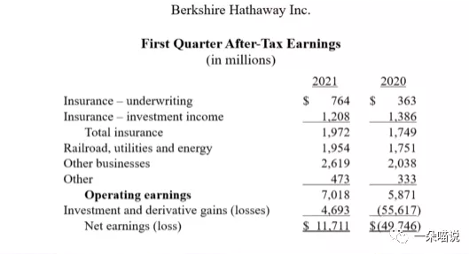

我从没想过会看到这样的亏损数字。回想起来，我努力回想我是否在去年一季度去度假了，是否把事情交给了其他的人，但我查了日历，那就是我做的。而今年的数字是正的117亿，不过这两个数字本身都没有太大的意义。

几年前，会计准则委员会对伯克希尔这样的公司的未实现收益或亏损进行了调整，但它们并没有计入损益表。但在几年前，这条规则又改变了：每次股票上涨或下跌，它都会进入我们的损益表。所以在去年第一季度，当股票大幅下跌时，我们有一笔巨大的未实现收益，这是非常大金额的未实现亏损——一般来说，当你开始说这样的话，你就会开始失去信任你的人了。但是同样一个会计科目，今年确是温和的增长。但如果需要我们每天公布损益表，那你会看到在某一天的我们的收益是30亿，然后第二天就会亏损20亿。所以，这是一种我们认为不是特别合适的会计处理方法，但这又是必须的。我们已经非常仔细地解释了这一点，无论是在我们的新闻稿中，还是我试图在信中解释为什么我认为这不是看待伯克希尔的方式。

我们认为随着时间的推移，我们将获得投资收益，原因我在过去的股东信中已经列出了。我们拥有的这些股份公司，他们往往有很多留存收益，然后他们使用这些留存收益进行再投资，而他们这样做通常对我们有利。因为总有一天，这会体现在资本收益上。对于一家拥有大量上市普通股的像我们这样的公司来说，你往往不想看损益表的最后一个科目，你应该关注的是营运收益。

现在，我想说的是，如果你将去年的前两个月与今年的前两个月进行比较，这些数字本来是相当可比的。但众所周知，在2020年3月，整个经济被关闭了。我的意思是，这是一场自我引发的衰退，而且是突然发生的。因此，美国经济跌下了悬崖。而在去年3月份，美联储的行动以一种非常有效的方式使经济复苏。稍后关于国会的财政问题，我们稍后会讲到。但你看到的数字差异，基本上是发生在3月份。我们的业务将在稍后介绍更多细节，但我们的业务确实做得相当好。要知道，这对制造业来说是一场非常、非常、非常不寻常的衰退，达到了异乎寻常的程度。

现在，在经济的很多领域，生意都非常好，我们稍后会讲到。但如果你从事的是少数几种真正受到重创的行业，那就仍然存在问题，比如国际航空旅行之类的。我们也许在稍后一些问题中，将再谈到这些数据。

我想再谈两件事，我特别希望新进入股市的人仔细考虑一下，特别是在他们尝试每天做30或40次交易以便从看似简单的游戏中获利之前再仔细考虑一下。所以我想转到L1幻灯片。请工作人员把它放出来。

**图：20家市值最大的公司（截止至2021年3月31日）**

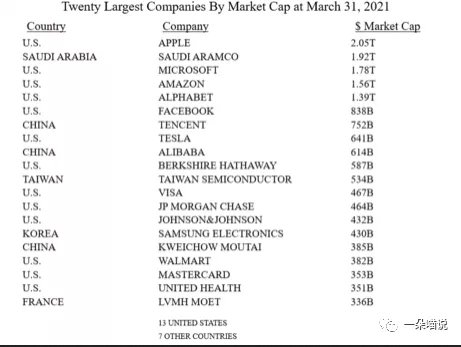

在今年3月31日，我列出了世界上市值最大的20家公司的名单，其中很多都是大家所熟悉的，但苹果公司是领头的，它的市值略高于2万亿美元。排在第20位的企业，市场价值3300多亿美元，但以上这些是截至3月31日世界上市值最大的20家公司。

现在，我希望你们认真看一下这个列表。排名第一的是苹果，然后表中的沙特阿美是一家在能源领域非常专业的公司——虽然我不知道它95%的股份是归政府所有还是什么的，但它本质上就是相当于一个可供出售的国家。但排名前六位的公司中，有五家是美国的。所以当你听到人们说美国没落了，或它没有很好地运行或诸如此类的事情，请你们记住，在整个世界上的六家顶级公司中，有五家在美国。

如果你想一想——我们去年讨论了一下这个问题，但在1790年，我们的人口只占世界人口的1%，我们有400万人左右，其中60万人是奴隶，连爱尔兰的人口都比美国多，那时候俄罗斯的人口是美国的五倍，乌克兰的人口是美国的两倍。所以我们在美洲大陆，我们有什么呢？我们只有一张关于未来、关于理想的蓝图。在宪法公布232年后，世界前六大公司中有五家是美国的公司。这可不是意外。这也并不是因为我们变得更聪明，更强大，或诸如此类的东西。我们有肥沃的土壤，我们有舒适的气候。但我提到的其他一些国家也是如此。整个系统的运行效果好得令人难以置信。想象一下，世界上最大的六家公司中的五家，存在于一个几百年前只占0.5%全球人口的国家。

如果你们愿意的话，请花一两分钟看看这份名单，然后做一个估计，自己猜测一下，30年后这些公司中有多少会出现在名单上。你们认为这些强大的公司，还有多少家会在名单上？嗯，我想不会是同样的20家公司。

**图：1989年全球20家市值最大的公司**

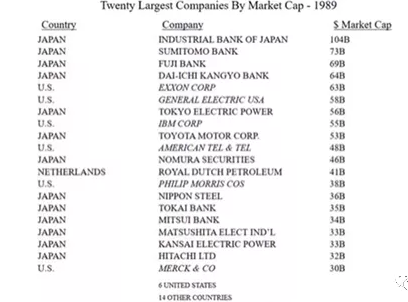

我现在请大家看一下幻灯片2，它可以追溯到30多年前。如果你们看看1989年的全球市值前20的公司，有两件事应该引起你的兴趣。第一，30年前的市值排名前20的公司都不在目前的名单上，一家都没有。第二，当时名单上有6家美国公司，它们的名字大家都很熟悉，比如通用电气（General Electric）、埃克森（Exxon）、IBM等。而这些公司，它们现在仍然存在，但默克公司排名下降了……30年后，没有一家公司上榜。我猜你们中很少有人会想到这点——我也想不到，但这件事提醒我们很多意想不到的事情可能会发生。这对你们来说应该是很明显的事情。

当时，日本的牛市持续了很长时间，所以我们有很多日本公司在名单上。而在今天，一个也没有；当时美国有6家公司上榜，现在我们有13个——但它们不是同样的6家公司。

好吧，这告诉了你一些关于平等的事情，这在这个国家是一个热门话题。它还会告诉你一些关于通货膨胀的信息，但这并不是一个高通胀时期。但它告诉你，资本主义运作得非常好，尤其是对资本家而言。这是一个相当惊人的数字。你可能会想未来30年同样的事情会再次发生——如今你们可以用2万亿美元买下苹果，但30年后要想再排名第一的公司的市值也许是现在的30倍。是啊，这似乎不可能，发生的，但我们对自己的信心就像1989年的投资者和华尔街一样，而世界可以以非常戏剧性的方式发展改变。

在你们开始对自己过于自信之前，我再给你们举一个你们可能会思考的例子。顺便说一句，这表明指数基金的一个重要论点，这个论点就是，投资者要做的主要事情就是“登船”。如果人们都要去一个更好的乐土，你只需要知道哪一个地方是必须要去的，然后登船——你不需要做很多其他事情。如果你有一个多元化的股票组合，比如美国股票——那是我的偏好，但要持有30年以上。但是如果你认为成功必须要知道很多关于选择哪些公司的知识，或者需要知道要选择哪些基金经理——你往往需要付给他们很多钱，他们才告诉你他们最好的想法，我的建议是，在1989年你不一定需要这样做。

总体来说，股票绝对是个好去处。但是，人们总是被各种行业极大地吸引。我的意思是，他们认为，如果一家公司说它属于XYZ行业，而且是一个受欢迎的行业，那么投资者就可以通过出售IPO，通过出售SPAC（特殊目的收购公司），并且不需要关注销售数字或盈利数字而大赚一笔——无论如何，这是投资该去的地方。

那么，如果伯克希尔哈撒韦公司回到1903年的时候，那应该在哪里投资呢？我父亲出生于1903年，但那并不是什么大新闻。事实上亨利•福特（Henry Ford）在1903年创办了福特汽车公司。虽然他之前失败过几次，但他即将改变世界。我是说，汽车将改变世界。你想一想，这关系到一家伟大的汽车保险公司的诞生——如果没有汽车，我们就不会有GEICO。但汽车改变了这个国家。而亨利·福特则带来了每天5美元的工资。这在当时是一件大事。然后，各种汽车生产线都出现了。

所以，让我们假设你在1903年快速浏览了一下所有的州际高速公路，在未来美国将有2.9亿辆汽车在路上行驶，你还浏览了关于汽车行业的一切，然后你说，“好吧，这很简单。这将是汽车的时代。”

在伯克希尔，我们有一家公司叫Marmon，是几年前我们从普利兹克家族那里买来的。普利兹克家族通过收购很多很多的公司建立了自己的事业，他们的公司的名字是Marmon。我不知道为什么杰伊和鲍勃决定用Marmon这个名字，但他们确实拥有一家名为Marmon的公司。他们拥有Marmon这家公司，并在1911年，这家公司的车赢得了第一个印第安纳波利斯500比赛（注：印第安纳波利斯500被称为美国赛车史上最壮观的赛事）。

也许这就是为什么他们叫它Marmon。我们为公司在1911年赢得第一个印第安纳波利斯500而感到自豪。同时，Marmon也是发明后视镜的公司——我不确定这是否是对社会的巨大贡献——但是在当时，那辆参加印第安纳波利斯500比赛的车，那个平时坐在车手旁边，负责向后看然后告诉赛车手在做什么的家伙，他生病了，所以他们发明了后视镜。

让我们假设你已经认可了汽车是一个不可思议的东西。总有一天会有印第安纳波利斯500比赛，总有一天他们会在车上装上后视镜，也总有一天，2.9亿辆汽车将在美国的高速公路上奔驰。

**图：美国历史上的汽车制造商（以Ma开头）**

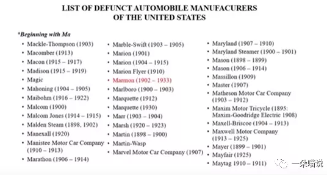

所以我决定回顾一下历史，我想我应该列出这些年来的汽车公司名单。我本来打算只放那些字母M开头的公司，我原本打算把它们放在一张幻灯片上。但是当我去翻看字母M开头的公司的时候，我发现名单太长了。所以我决定列出以字母Ma开头的公司，正如你们所看到的，这上面有将近40家公司进入了汽车行业，你们可以看到我们的Marmon公司，它生存了一段时间，但它在20世纪30年代销售的汽车确实很特别。但无论如何，至少有2000家公司进入了汽车行业，因为它显然拥有令人难以置信的未来。当然，你还记得在2009年，有三家公司倒闭，其中两家破产了。因此，选股远比确定未来什么会成为一个出色的行业要难得多。

Maytag公司推出了一款汽车，Allstate也推出了一款汽车，杜邦公司也推出了一款汽车。我的意思是，在内布拉斯加州，有内布拉斯加州汽车公司。很多人都开了汽车公司，就像现在很多人在做的一样，因为你可以从别人那里得到钱。但是，只有非常非常非常少的人选出了获胜者并得到了继续投资的机会。

在福特汽车公司，亨利·福特有几个合伙人，他不喜欢他们。所以他想出了一个让他们退出的方法。这就是汽车金融的开始。这说来话长，我们今天不会讨论这个，但在当时你没有办法购买福特汽车公司的股票。当然，最后通用汽车成为了其主导公司。因为亨利•福特在推出T型车后再推出A型车的时候，他的工作做得不是很好。所以我只想告诉你，这个行业并不像听起来那么容易。

好了，我们会去找Becky Quick，她会问我们四个人中的任何一个问题，这些问题都是她选择的，也是她没有告诉我们的。我们将在相当长的一段时间内这样做。你可以向她提问。然后，在大约三个半小时之后，我们将举行年会，这不会花很长时间。所以Becky，到你了。

**问答环节开始**

**1、目前仍然不想拥有航空公司**

**Becky：**谢谢沃伦。大家好。第一个问题来自Andy Seas。他说他持有的B股还远远不够。

他说，“巴菲特先生，你的名言是当别人贪婪时要恐惧，当别人恐惧时要贪婪。但从所有迹象来看，在其他人最害怕COVID-19爆发的最初几个月里，伯克希尔却在恐惧，在低位或接近低位时抛售了航空股。你们没有利用当时市场的恐惧，以极低的折扣购买上市公司的股票，并且在以极具吸引力的价格回购大量伯克希尔股票时犹豫不决。我很想听听你对这次事件的看法，以及在通过《关怀法案》(CARES Act)确保政府将为金融市场提供强有力的支持之后，伯克希尔公司是如何做出决策的。”

**巴菲特：**直到货币和财政政策开始发挥作用，我们知道我们遇到了一个令人难以置信的麻烦。

就像查理是首席文化官一样，我是伯克希尔的首席风险官。那是我的工作。我们希望我们做得很好，但我们想确保我们不会做得太糟。但我们并没有卖出很多。

我的意思是，我们是一家拥有可能价值7,000亿美元业务的公司。有些公司我们拥有它们的全部，有些公司我们拥有一块，我不知道我们是否只卖出了当时我们所有业务价值的1%。

关于航空公司，在这里我会讲到财政货币政策做了什么。我们在伯克希尔的不同子公司有一些人，他们想要从政府那里寻求帮助。还有一些拥有百分之几股份的小股东们说，“我们将会被正在出台的法规和经济停滞所带来的后果所扼杀。”

他们说，所有人都在寻找政府的帮助，那我们为什么不去呢？我说，“伯克希尔可以处理这些麻烦，政府的救济是为那些无法处理正在发生的事情的人准备的。”所以我们没有申请救济，但是航空公司是最主要的受益者。很快，航空业得到了第一阶段的250亿美元救济，其中大部分给了四大航空公司，还有一些是赠款，而不是贷款。

我认为这是很好的公共政策。我希望它能普及到每一家餐馆和干洗店，以及每一家真正停业的小企业。他们基本上被疫情击垮了。但对于航空公司来说，显然正在发生的事情不是他们的错。这不像2008年和2009年那样，人们指责银行，不愿看到政府向它们提供帮助。

现在几乎所有的航空公司都处于破产状态。而前四大航空公司中有三家在过去也曾破产。因此，航空业已经习惯于面对破产的风险经营。（在疫情打击下），他们本可以继续经营下去，但得到政府的帮助也是无可厚非的。

整个航空业——对比苹果的2万亿市值这些数字——整个四大航空公司，他们差不多市值在1,000亿美元左右。我的意思是，这个行业相对而言是非常非常小，即使它们的市值都加在一起也不会在前50名。

所以无论如何，政府介入了，他们需要政府的帮助，否则他们会破产。而面对国会提出的救济方案，他们决定他们应该得到帮助，关于这点我一点儿也不反对。但想象一下，如果伯克希尔一直持有它们10%的股份，那么也许会有人说，“你们去找伯克希尔吧。”

如果他们有一个非常富有的股东，拥有8%或9%的股份，他们可能会有一个非常不同的结果。而如果他们去寻找政府救助的时候没有这些，那可能不会得到同样的结果。

我的意思是，因为你们已经看到了一些公司的头条新闻，它们拿了一两个亿，但实际上它们并不需要这一两个亿。虽然它们中的一些公司把政府救济金给还回去了，但在这个例子中，你们实际上看到的结果可能与我们选择继续保留股票的结果不同。但无论如何，一个市值不到1,000亿美元的行业，它们在疫情中损失了大量的资金。

他们损失可持续的赚钱能力。目前，国际旅行还没有回归，但我想对它们说，经济复苏可能比你们预期的要好得多。

另外那时我们不喜欢在银行业里投入那么多资金。所以我收回了一些银行的投资，但基本上只是我们总规模1%或1.5%左右的净卖出。

虽然现在回过头来看，最好还是买入，但我当时没有考虑。我不认为这是伯克希尔历史上的伟大时刻，但我们的净资产超过了美国任何一家公司。根据会计原则。我们有6000亿或7000亿美元的好生意。我认为航空业因为我们的卖出而过得更好，我希望他们好，但现在我仍然不想买下航空业。

人们真正想要旅行是出于个人原因，而商务旅行则是另一回事。我们拥有美国运通19%的股份，并拥有精密铸件公司（Precision Castparts），这些公司为航空业务提供了很好的服务。所以我们在航空旅行方面仍然有很大的投资，也对它们有很大的承诺，但我们希望四大航空公司一切顺利，我认为它们的管理层在这段时间里做得非常好。

**2、我们本可以在美联储行动之前进行投资**

**Becky：**除了关于航空公司的问题以外，还有一个问题——有几个问题问到了这方面，其中一个来自于Chris Blaine。他问，“你花了多年时间积累了很多现金，并认为自己已经准备好了猎象枪并随时狙击大象。但在2020年3月，当股票市场出现了抛售、美国政府承诺会采取一切必要措施时，你却袖手旁观。请问这是为什么呢？你为什么不充分利用手头的现金？”

**巴菲特：**我们手头的现金约占我们企业价值的15%。这是一个健康的数字，并且我曾说过，它永远不会低于200亿美元。现在我们将提高这个数字，因为这和伯克希尔的规模和重要程度有关。

就在美联储采取行动之前，我们本可以部署500亿或750亿美元的投资。当时已经有两个（潜在收购机会的）电话打进来了，但在那两到三天的时间里，似乎什么都不可能发生。

然后杰伊·鲍威尔（美联储主席）开始了他的行动，而这是非常重要的。我想说的是，美联储采取了行动，他们在3月23日的行动迅速而果断。这改变了经济停滞的局面。当时的政府债券市场受到了疫情的严重干扰，伯克希尔公司甚至没办法在那段时间发行债券（注：伯克希尔的评级非常高）。新闻媒体对此报道的不多，但货币市场基金在这段时间出现了挤兑，非常严重的挤兑。

如果你看看当时每天的数字，那就是2008年9月的重演——当时，我对伯南克和保尔森他们所做的一切给予了极大的肯定。而这一次，美联储知道，他们需要付出一切代价也要救活市场——他们在3月23日也说出并展示了这一点。通过行动，他们把一个连伯克希尔都无法融资的债券市场，变成了连嘉年华游轮公司（注：该公司受疫情影响严重）都可以随意融资的地方，其中包括创纪录的公司债券发行，涉及到亏损公司、破产公司等等，这是你能想象到的最戏剧性的举动。当时，我记得国会主席说过，“在财政方面提供一点帮助怎么样？”然后国会再次采取了非常非常大的行动。

在2008年和2009年，他们还会争论说，“我们不想给那些肮脏的银行任何钱”，但这次疫情真的不能怪任何人。所以他们看到了什么是必要的，然后国会做出了回应。因此，财政和货币政策的反应和行动令人难以置信，它们很好的完成了任务。我认为这些政策的效果比美联储或财政部或任何人预期的都要好。现在的经济，85%都在高速运转，我想你们将会看到一些通货膨胀。美联储、国会它们以一种令人难以置信的方式做出了回应。我们从2008年和2009年学到了一些东西，然后这次我们应用了它。但我不认为这是肯定会发生的事情。

关于伯克希尔的一件事是，我们不想依赖任何人。我们也不是银行。如果我们需要钱，我们也不能去找美联储。我们必须确定，在任何情况下，我们都能够生存下去。如果你还记得，布兰奇·杜布瓦在《欲望号街车》中说过，“我总是相信陌生人的仁慈。”但如果糟糕的事情发生了，你可不能依靠来自朋友的善意。我在很多地方都看到过类似的场景。

我们在三月中旬看到，当时每个人都在提取信用额度以度过难关，而银行没有预料到这一点。人们不确定自己能否在10天后继续提取信用额度，所以他们就把钱提出来投资在货币市场基金上。

我对所做的货币和财政方面的工作都给予了很高的评价，但我不认为这是一件“必然如此”的事情。在当时，我根本不知道该怎么实施。还好最终起作用了。我认为它比任何人预期的都要好，我想你们现在也看到了成果。

查理对此也有一些看法，谈谈吧。

**芒格：**如果有人认为，一旦市场陷入某种疯狂的危机，我们在市场最底部的时候能够把钱都花光进行抄底，那真是疯了。总是有一些人偶然会成功，但这是一个太难的标准。任何人如果对伯克希尔哈撒韦抱有这样的期望，那他就是疯了。

**巴菲特：**是啊，查理。查理和我从来都不擅长抄底，但这是因为我们是真的不会抄底。

**芒格：**是的，我们不能。顺便说一下，几乎没有人能做到。

**巴菲特：** 在管理几百亿或者几千亿下是根本不可能的。但伯克希尔现在就很好。我们忘了展示其中一个财务方面，实际上，如果你回到资产负债表，我们确实在底部回购了不少流通股。

我们在第一季度花了大约250亿美元，之后又花了更多钱，这是最好的事情。我们无法以像回购自己的公司那样便宜的价格去并购公司或者购买股票。所以，我们花了不少钱进行回购，但回想起来，我觉得我们本可以做得更好。我们本可以卖掉航空公司，削减银行股的头寸，而我们是否应该同时买其他东西是另一个问题。

**3、伯克希尔长期表现会更好，但巴菲特向普通人推荐指数基金**

**Becky：**这个问题来自一位长期股东，他持有伯克希尔已经超过25年了。他的名字是Ben Nowell，他来自明尼苏达州的明尼阿波利斯。

他说，“芒格先生和巴菲特先生，你们在经历了15年的市场低迷后，对预测伯克希尔未来能够跑赢市场持谨慎态度。考虑到这一点，你认为长期股东继续持有股票的理由是什么？为什么不通过指数投资分散风险呢？”

**巴菲特：**查理，你想回答吗？

**芒格：**嗯，没问题。我个人更喜欢持有伯克希尔，而不是持有指数。我很放心的持有伯克希尔。我认为我们的业务优于市场平均水平。

**Becky：**那你是否认为市场对它的估值是错的？

**芒格：**好吧，其实这些都只是历史的偶然，股价一直在波动，但综合来看，我认为伯克希尔会表现优于市场，即使巴菲特和我离开人世。

**巴菲特：**我推荐标普500指数基金，并且长期以来一直向人们推荐。我从来没有向任何人推荐过伯克希尔。因为我不想让人们买伯克希尔，仅仅是因为他们认为我在推销伯克希尔。可无论如何，关于伯克希尔的一切情况，我都告诉全世界了。

我死后，会有一笔基金留给我的遗孀，其中90%将投资于标普500指数基金，10%投资于国债。另一方面，我很高兴能在我死后的12年左右的时间里，继续为慈善事业捐款，让绝大多数股份留在伯克希尔。我认为长期来看伯克希尔会跑赢指数。我喜欢伯克希尔，但我也认为大多数人不具备选择股票的能力。

**巴菲特：**在50或60年前，我们的合伙企业清算的时候，有一大群投资人没有选择持有伯克希尔的股票，他们选择了查理，并让查理继续为他们管理资金。

所以我们有一群非常不寻常的股东。我认为，他们把伯克希尔视为一个终生储蓄工具；同时，他们并不需要过多的关注伯克希尔，并且他们相信，即使他们在10年或20年里不管它，我们仍然会把他们的资金处理得相当好。但我不会说，随着时间的推移，标普500指数能够跑赢伯克希尔。我更喜欢伯克希尔。

但我认为，一个对股票完全不了解的人、一个对伯克希尔没有任何特殊感觉的人，我认为他们应该买标准普尔500指数。

**4、巴菲特将遗产中的绝大部分配置在标普500上**

**Becky：**下一个问题来自Gerald Silver。他说，“我相信你已经指示你的财产受托人将大量资产投资于指数基金。这难道不是对你的投资经理投了不信任票吗？”

**巴菲特：**嗯，其实我们谈论的仅仅是我1%的遗产的归属问题。顺便说一句，所有的富人都会得到律师的建议，建立信托，这样就没有人能看到你的遗嘱之类的东西。但我的遗嘱将被公开，你们将能够在某个时候看到我遗嘱的全部部分——大概我99.7%的财产要么捐给慈善机构，要么捐给联邦政府。

在此之前，我认为，伯克希尔是一个很好的持有对象。但对于特定的个人，特别是我的妻子，我只是觉得，只需要我遗产中的一小部分，就足以让她在今后的生活中过得很好。我只是认为最好的办法是将当中的90%配置中标普500上。

现在，那些指数基金的管理者随着时间的推移，已经开始推出了越来越多的产品，这些产品与其他指数和其他产品挂钩，所以他们开始对美国公众说，“嗯，你可以选择在哪个洲投资，或者你可以选择什么行业，然后我们可以卖给你特定的指数基金产品。”

当他们刚刚告诉你，如果你真的不懂什么股票，那就简单的购买整个指数吧。所以我把标普500指数作为一个基准指数。

但总体来说，这只是占我总遗产中的很小的一部分，但这将是我遗孀的全部——她将拥有她所需要的所有钱，而且远远超过自身的需求。这就是我想说的。对于我遗产中的99.7%，将和现在一样，捐作慈善事业用途，这些遗产会以伯克希尔公司股份的形式存在，直到它们最终被处理掉。

**5、投资雪佛龙不涉及道德判断**

**Becky：**这个问题来自英国的Andrew Dickson。他说，“我的问题是关于石油和天然气业务，以及你购买雪佛龙的股票。在1997年你被问及烟草股票相关问题时，你提到个人和公司偶尔要对他们愿意做的事情划出道德界限。你当时表示，你不愿意在烟草股票上做出大的投资，你对它们的前景感到不安。查理还提到了一桩私下的烟草交易，你们都知道这是件轻而易举的事。然而，你们两人都没有后悔对交易说‘不’。”

“我并不是说石油和天然气行业与香烟一样，没有负面的外部效应。但就烟草而言，其产品与癌症之间的因果关系是直接、明显和可衡量的。而对于碳氢化合物，社会成本和收益的评估要复杂得多。然而，社会中越来越多的人以这样那样的理由认为，碳氢化合物应当在投资中被排除在外。”

“我的问题是，气候界的危言耸听现在是否已经在全社会蔓延到了非理性的程度？在向更绿色的能源过渡方面，我们是否就可实现的变革步伐达成了不切实际的共识？在某种程度上，这正成为当前年轻一代负担的一种过于昂贵的税收。从你购买雪佛龙股票的行为中，我们可以看出你似乎并不相信社会上的抱怨？未来10年，监管机构和政客对碳氢化合物的前景肯定不太友好，就这一点而言，会影响到雪佛龙。在这样的背景下，投资者还能认为，以低成本发现并生产石油的油气企业在未来很长一段时间内都能产生足够的资本回报吗？”

**巴菲特：**好吧，我给你10个字的答案。我不记得所有的问题，但我想说的是，持很极端的不同观点的人都有点疯狂。我讨厌在三年内禁止所有碳氢化合物，这在现实世界中是行不通的。

另一方面，随着时间的推移，正在发生的事情将会适应时代，就像我们已经适应了各种事情一样。我感兴趣的是你引用了我在1997年说过的话，因为我们以前讨论过这个问题。

我们对拥有好市多或沃尔玛感到舒适，虽然他们有大量的商店在卖香烟，香烟是他们收入的重要来源。香烟可以吸引人们进入门店，他们知道香烟的价格，好市多和沃尔玛把香烟摆在柜台前面。所以这是一个非常艰难的局面。我们很久以前就做出了这个决定。

当年我们去孟菲斯的时候，我们看到了一家非常非常好的企业，而且它的危害要小得多。至少从我能发现的一切来看，它比吸烟、咀嚼烟草的危害要小得多。这些人都是正派的人，他们经营着合法的生意，他们自己也嚼烟草。他们告诉我，他们的母亲有一百岁了，也嚼烟草，以及所有这些事情。但查理和我去了酒店大堂，我们对自己说，这可能是我们见过的最好的生意。我打电话给我当时的女婿Allen Greenberg，他在为一个与北约有关的组织工作时曾研究过咀嚼烟草及其影响，然后我们决定不做这件事。

但我过去常常在我们的报纸上看到金融公司的广告，我知道它们很糟糕。决定是否从事这一个行业是一件非常困难的事情。这是一个非常艰难的时刻，决定哪些公司比其他公司更有利于社会。

但我认为雪佛龙以各种方式造福社会，我认为它将继续这样做，我认为我们将在很长一段时间内需要大量的碳氢化合物，我们将非常高兴我们已经拥有了它们，但我确实认为，世界也在远离他们，但这也可能会有所改变。

我不喜欢对股票进行道德判断，从实际经营业务的角度来看，但每个行业都有你不喜欢的东西。比如肉类包装工，不知道你有没有去过肉类加工厂？那你是否也要做出什么道德评判呢？

如果你期待完美的投资，即使你的配偶或朋友在公司内部，你也很难找到。如果你投资指数基金，你又怎么选择指数里应该包含什么公司呢？

雪佛龙公司不是一个邪恶的公司，我对拥有雪佛龙公司一点也不感到内疚。如果我们拥有整个企业，我不会对从事这一行业感到不舒服。查理？

**芒格：**嗯，我同意。你可以想象两件事。一个年轻人将成为你的女婿，他可以是斯沃斯莫尔大学的英语教授，或者也可以是在雪佛龙公司工作。你会选哪个？我想承认，我会选在雪佛龙工作的那个。

**巴菲特：**我希望你的女儿们同意你的观点。

**6、伯克希尔是全美最大的基础设施建设者，履行了减少碳排放的承诺**

**Becky：**在争论的另一方，这些关于这些ESG问题，我收到了来自持有不同的观点的双方的大量的电子邮件。这个问题来自Christina Gallegos，她从2018年开始成为股东。

她说，“关于会议议案的第二项和第三项，董事会建议对关于要求伯克希尔报告气候相关风险和机会的股东提案投反对票，以及对股东多样化和包容性的提案投反对票。在金融知识普及和通过财富创造增强权能方面，伯克希尔是一支如此强大的正义力量。在这两个非常重要的问题上，为什么不成为一股向善的力量和一个榜样呢？请与我们分享有关‘反对’建议的更多信息。”

**巴菲特：**好的，我想Greg也许可以谈谈伯克希尔在环境方面所做的工作。我想说的是，这非常有趣。就目前的情况来看，我认为我们很可能有超过100万的股东。

我收到了股东写给我的信，我想去年我收到了不止3封来自股东的信。我们对此的投票结果，你们稍后会看到，绝大多数用自己的钱购买伯克希尔的人投票反对这些提议。而大多数投赞成票的人从来没有把自己的一分钱投入伯克希尔。

所以我认为他们没有读过我们的年报，我认为他们没有读过伯克希尔哈撒韦能源公司的报告。我不认为他们知道，如果我谈论我们在高压输电方面所做的，我们比国内任何一家公司都做得更多。总统也谈到了政府将要对此（高压输电建设）做什么，以及这有多么重要。

总的来说，我们的记录非常好，但我们有一群组织——他们都是好人，但他们希望我们按照他们的方式回答一堆问卷。所以他们想让我们的Dairy Queen和Borsheims，以及所有公司为他们填写报告，只是为了让这些报告显示一堆数字。可真正重要的是Greg提供的关于伯克希尔哈撒韦能源和铁路的报告。

他们谈到了我们的三家公司，这已经涵盖了伯克希尔整体的95%。坦率地说，在我看来，这是愚蠢的。现在我们会做一些其他愚蠢的事情，仅仅是因为我们被要求这样做。

所以，我们会做任何需要做的事情。但要Business Wire、Dairy Queen、以及所有这些地方的工作人员为了这些数字而专门做报告？我们在伯克希尔不做这种事。

在疫情期间，我们可能只有大约12个人来到总部，而我们有360,000人在子公司工作，从事各种不同的活动，伯克希尔就是这样建立起来的，是建立在自治的基础上的，我不想干涉它。在标准普尔500指数成分股公司中，我可能是唯一一个没有每月收到综合损益表的CEO。标准普尔500中的其他公司，我敢打赌，他们在2月和3月的综合损益表，公司的CEO和很多其他高管都得到了这些数据。

我们没有这个。我不需要它们。即使它们给了我每个月的经营数据，该发生的麻烦仍会发生；实际上，它们想要告诉我的月度经营情况，我早已心中有数。因此，它们是否提供月度损益表，对我来说没有任何区别。

这些子公司能够自负盈亏。所以我们不会仅仅因为我们有相关的这样的部门，或者那样的部门就去让子公司做事情。我们可不想设立很多这样的部门。

最重要的是我们在伯克希尔哈撒韦能源公司和铁路公司所做的工作。我会让Greg待会告诉你，但我们——

**芒格：**我不认为我们知道关于全球变暖等所有这些问题的答案。问问题的人认为他们实际上知道答案。我们只是更谦虚。

**巴菲特：**好吧，但即使我们知道答案，就我们会做什么报告而言……我们也不会收集一大堆对我们来说毫无意义的东西，来满足那些实际上自己没有任何伯克希尔股票的人的需求。在大多数情况下，我可以告诉你，他们甚至没有读过我们的年度报告。正如我在年报中指出的，很多人会认为我们只是在炒股。

根据会计准则，伯克希尔哈撒韦公司拥有很多的固定资产、工厂设备、商业基础设施——而总统刚刚在周三晚上谈到了基础设施方面、IT建设方面的重要性。以会计准则来衡量，我们在这方面的投入比美国任何一家公司都多。我们的在固定资产和基础设施方面的规模超过了美国上市的所有公司，而且我们的优势很大。因此，我们实际上投资了使得这个国家前进和运转的东西。

15%的州际货物通过我们的铁路运输，而我们正在建设运输系统。我们从2006年或2007年开始，计划着该如何关闭燃煤电厂，但如果你无法把可再生能源的发电传输给客户，那你就不能关闭燃煤电厂。如果你要在怀俄明州发电，把电力运输去拉斯维加斯或其他地方——以前他们在附近有一个煤电厂，因为这是50年前、或75年前的方式——你最好有良好的输电网。否则，在怀俄明州刮大风是没有意义的，因为如果没有输电网，在拉斯维加斯人们也没办法开灯。

所以我们在很早之前就提出了输电计划的问题，我们在正在进行的年度报告中说我们投资了160亿，并且自从年度报告出来后，我们又增加了20亿的投资。而在美国也没有什么人在这样做公共设施建设。

我说的差不多了，Greg你说说吧。

**Greg Abel：**好的，沃伦。谢谢。实际上，正如沃伦所提到的，当你想到伯克希尔时，BHE和BNSF有着显著的碳排放的足迹。

沃伦，你刚刚谈到了我们过去提供的信息披露，可以一直追溯到2007年。我找出了两份给投资者做的演示报告，一份是2007年的，然后是我们最近的一份是2021年的。从2007年开始，我们一直在为我们的固定收益投资者做投资者演示报告——直到2021年，我们每年都在做。我们每年都会向董事会披露类似的信息，并就伯克希尔哈撒韦能源公司（BHE）的脱碳计划进行了讨论。

现在很有趣的是，如果你看一下2007年的固定收益投资演示报告，我们当时正在召开会议，我们有第三方债务——即我们的公用事业通过公开市场筹集的债务，这是我们所有受监管实体所使用的传统资本结构。我们做投资者演示报告，目的是用于管理我们对客户的总债务成本。所以我们有固定收益投资者，我们每年向他们展示经营情况。

如果你回顾一下2007年的投资者会议，就会发现这很有趣。在那个演讲中，我们强调了气候变化风险。它是一个根本性的风险，我们讨论了什么是好的政策。我们讨论了创新，讨论了市场转型，以及在那个时间点设定目标的重要性。同时，我们对我们的行业提出了建议。

从那时起，我们每年都会提出一项计划和战略，围绕我们在BHE的每一项业务，以及我们的每一个受监管实体，我们会去谈它们将如何转型。我们的整个转型一直围绕着去碳化，不仅代表着我们的利益相关者，还代表着我们在许多州服务的客户管理相应风险，并最终为伯克希尔哈撒韦的股东管理相应风险。

现在，当你回顾这些演示报告时，它们都有一个共同的主题——沃伦刚刚已经谈到了。你必须先做好基础设施建设，而这个基础设施建设就是围绕着建立高压输电系统所开展的。

沃伦在今年的年度报告中提到了这一点。他在信中强调，在伯克希尔哈撒韦能源公司（BHE），仅仅是在西部，我们将投资180亿美元在电网建设上。当我们今天坐在这里的时候，我们已经完成了其中的50亿的投资；剩下的130亿美元将在未来10年内继续投入。这是基础设施的建设，然后我们才能继续围绕可再生资源发电进行投入，并将其产生的电力，转移到我们在伯克希尔哈撒韦能源公司（BHE）服务的许多州，以及更远的地方去。

我要强调的是，在我们建设输电基础设施的同时，我们也一直在建设可再生能源发电设备。如果你看一下我们到2020年底的投资，我们已经投资了300亿美元，或者说在可再生能源方面投入了超过300亿美元，并且已经真正彻底改变了我们的公用事业业务的经营方式。它们一直在脱碳，并向我们的利益相关者和客户提供有价值的产品。

我认为结果真的很惊人。当你看到这些数据的时候，我会给你几个要点。如果你回到2015年，当美国加入《巴黎协定》时，制定了非常具体的目标。在制定这些目标之前，伯克希尔哈撒韦能源公司（BHE）和其他12家公司，包括世界苹果公司（Apple of the World）、谷歌（Google）、沃尔玛（Walmart）等，承诺在《巴黎协定》下开展业务。伯克希尔哈撒韦能源公司是2015年参与协定的公司之一。

**Becky：**其中有多少公用事业公司？

**Greg Abel：**当时没有其他能源公司做出任何类型的承诺，我很高兴地告诉大家，我们做出了各种承诺。其中之一是，在那时，我们在可再生能源上投资了150亿美元，而我们总共将承诺300亿美元。截至今天，我们远远超过了这个总数。因此，我们有明确的承诺，要减少我们企业的碳排放。同时，我们也专注于可识别、可量化的成果。我认为这非常重要。

如果你看看最初美国政府与《巴黎协定》相关的承诺所设定的标准：从2005年起，碳排放的目标是减少26%到28%，这个目标是到2025年之前。政府想要26%到28%的削减水平。而我们在BHE承诺了这一点。

我很高兴地向大家报告——沃伦，我们也向我们的董事会做出了简报，我们在2020年已经实现了这一点。因此，我们实现了我们的承诺，我们实现了《巴黎协定》下的承诺。

然后，如果看看现在发生的情况。关于重新加入巴黎协议的讨论中，本届政府再次提议，以2005年为起点，到2030年，减排目标应该是50%到52%。再次，我很高兴向我们的股东做简报，并向我们的董事会做简报，伯克希尔哈撒韦能源公司（BHE）将在2030年前实现这一目标。我们的碳排放削减将达到《巴黎协定》的目标。

同样，我们能做到这一点的原因是我们已经建立了输配电系统的基础。沃伦强调了大量投资，然后在可再生能源方面进行了非常具体的投资。

这里我有一个额外的幻灯片，我希望把所有的内容都结合起来，这是幻灯片。

**图：伯克希尔哈撒韦能源公司碳排放目标**

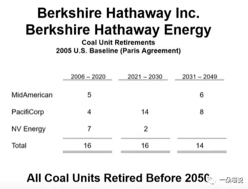

当人们讨论碳排放时，他们经常用到煤（Coal units）作为单位。比如你拥有多少，你减少了多少？毫无疑问，这是一个重要的衡量标准，但它是一个指标。

我们非常关注我们拥有的三个公用事业企业，以及我们在幻灯片上强调的，是我们现有的发电厂逐步过渡到通过电网传输的可再生能源的时间表。

我们没有过度依赖于利用天然气过渡的方案，这是一个明确的战略。所以再过一段时间，我们的煤炭机组就会退役。

我很高兴地向我们的股东报告，截至2020年，我们已经关闭了16个单位。如果你看看从2021年到2030年，将会有16个增量单位被关闭。然后如果你一直看到2049年底，我们剩下的14个单位将被关闭。在那个时间点，我们所有的煤炭单位都会关闭。

这张幻灯片只是汇总了我们每个业务部门为帮助实现这一过渡而开展的所有活动，我们最终会实现脱碳化。

这不仅仅有利于我们的客户，他们代表的在不同州的许多利益相关者，同样重要的是，这还代表了我们伯克希尔哈撒韦的全体股东为“去碳化”的努力。

我想补充的另一件事是，当你讨论伯克希尔内部的碳排放问题时，当你把BNSF和BHE结合在一起时，要注意它们是伯克希尔哈撒韦公司中前二大的碳排放实体。

BNSF也非常积极地管理他们的碳排放。他们已经承诺为2030年制定基于科学的目标。因此，这些目标将再次与《巴黎协定》保持一致。

我们已经看到了其他参与者或行业中的一些参与者所承诺的，我们的承诺将非常类似，即这将与巴黎协议一致：到2030年，BNSF的碳排放将减少30%。这个目标之前已经被公开披露，在BNSF的网站上。我所讨论的关于BHE的一切也都在他们的网站上，在8-KS中归档，我们的股东都可以自由调阅。

所以当我从我们伯克希尔股东的角度来看，我真的相信这个风险得到了很好的管理，我们正在为自己的长期发展做准备。谢谢，沃伦。

**巴菲特：**是的，顺便说一句，总统那天晚上谈到了1,000亿美元的基础设施建设。电力传输确实是个问题，是一个大问题。因为你必须从太阳照耀的地方和大风吹的地方，把电力运输到人口集中的地方，这涉及到跨越州界，以及高压电线很可能将穿过人们的后院。

联邦政府只是说，“这是我们要做的”，然后就把计划塞给地方州政府，然后让它们把计划完成。他们可能有这样的能力，他们将能够比我们更快地做到这一点。但另一方面，我们很乐意这样做。

我们将花费1000亿美元，但我们能做到这一点的速度并不快。我们在2006年收购了太平洋公司（Pacific Corp），让我们在遥远的西部有一批客户，他们有煤电厂为他们服务。而要改变这一点，你必须能够去起风的地方建立风力发电设备，然后通过输电网去传输电力。但这很有趣。我们已经公布了这一信息。在美国，我们在可再生能源和输电方面的支出远远超过任何公用事业。

我们一开始什么都没有，是逐步投入的。但是那些用自己的钱购买伯克希尔股票的个人投资者，他们似乎明白这一点，我相信他们阅读了我们的年报。

我们接到一些机构的电话，他们说，“好吧，我们想出来和你谈谈。”好吧，我们才不会和他们交谈呢。

不过，我们也没有忽视那些长期以来一直与我们在一起并用自己的钱购买了大量股份的投资者。我们也不会给予分析师或机构比个人更多的特殊待遇，因为这些个人投资者，基本上非常信任我们、并将他们的储蓄托付给了我们。

**13、芒格：极端货币行为最终将导致灾难**

**Becky：**接下来，Pat Kane问道，你对MMT经济理论有什么看法？特别是美元在作为世界储备货币的实践上？

**芒格：**好吧，我认为现代货币理论家过于自信了。我不认为我们中的任何人知道这些东西最终会发生什么。但我确实认为，这种极端行为很有可能超乎所有人的想象。但我也知道，如果你继续无限制地做下去，最终会导致灾难。

**14、浮存金的价值随着利率下降而下降**

**Becky：**在另一个相关的问题上，Elle Kandel也写到，“如果你能以更低的担保利率甚至是零利率借钱，那你还需要通过保险公司的浮存金借钱吗？”

**巴菲特：**低利率环境大大降低了浮存金的价值。我已经在年度信函中写到了这一点，我们的浮存金有一种几乎没有人拥有的灵活性，但浮存金的价值已经大幅下降，因为这一切都逃不开无风险利率。

当你进入负利率，如果一个国家可以以负利率借贷，你就会陷入困境，这有点类似于圣彼得堡悖论（译者注：圣彼得堡悖论是决策论中的一个悖论。圣彼得堡悖论是数学家丹尼尔·伯努利（DanielBernoulli）的堂兄尼古拉·伯努利（Nicolaus Bernoulli）在1738年提出的一个概率期望值悖论，它来自于一种掷币游戏，即圣彼得堡游戏）。这是一堆抽象数学的疯狂结果。

但是，现在你完全失去了利率作为地心引力。如果你告诉我，我将不得不以每年-2%的利率借钱给政府，我说的是名义上的数字，而不是……那么你实际上是在告诉我，如果我一直这么做，随着时间的推移，我会最终破产。所以负利率会推动着你去做其他的事情，当然现在我们也看到了。好吧，我们看到世界上其他国家以更极端的方式做这件事，但包括才华横溢的Paul Samuelson在内，没有人认为应该会这么做。我们不知道后果是什么，但我们显然知道最终有事情发生。

**15、伯克希尔现在在收购市场中没有优势**

**Becky：**这个问题来自Sam Butler，他说自己是伯克希尔的股东很多年了，他问，“这么多新SPAC的崛起对伯克希尔寻找和完成新收购的能力有什么影响？”

**巴菲特：**好吧，这是一个很关键的问题。按照我的理解，这些SPAC公司一般需要在两年内花完他们的钱。所以他们必须在两年内收购一家企业。

如果你用枪指着我的头说，你要在两年内完成购买一家大型企业，那我也会买一家，但那不会是一家真正的大企业。我们一直在关注收购机会，但我们看了又看，我们现在面临着许多来自私募股权基金的压力。我的意思是，如果你为别人运作资金，你会因此得到了报酬，然后你会因为收购公司而得到更多的好处却没有坏处，那么你肯定要去做收购。

我可以告诉你一个故事。有一个非常著名的人物很多年前打来的电话，打算进入再保险这个行业，想找我学习一下再保险的知识。我说，“嗯，我真的不认为这是一个很好的生意。”他说，“是的，但如果我在六个月内不花掉这笔钱，我就得把它还给投资者。”

所以这是一个不等的方程式。如果你用别人的钱工作，你会因此得到了好处，但如果你什么都不做，你就必须把资金还给他。坦率地说，（如果是这种情况）我们在这方面没有竞争力。

这不会永远持续下去。但这是现在的热钱所追逐的地方，华尔街会去任何热钱所在的地方。SPAC已经存在一段时间了，你在这些公司上贴了一个著名的名字作为标签，然后发现你可以因此而获得很多资金。我的描述可能有点夸张了，但这就是我们在赌博式的市场中所看到的。

事实上，我确实引用了凯恩斯的一句话，这可能是历史上最著名的名言之一，因为它确实总结了我们在市场中所看到的一个问题。

要知道，我们拥有世界上最大的市场。我的意思是，你们可以想象一下，如果你能够拥有世界上最大企业的一部分，你会今天投入数十亿美元，然后在两天后又拿出来吗？

我的意思是，平均而言，与农场、公寓、写字楼等需要数月才能完成交易的地方相比，现在市场提供了一个机会，让人们在一个非常非常低的成本基础上参与到这类资产中，获得即时的、巨大的反馈，这当中可能也存在各种各样的机会。但如果他们能让赌客进来，他们就能赚到真正的钱，因为他们为赌客提供了更多的工具，而赌客们愿意支付愚蠢的费用和各种各样的东西。

所以你有了SPAC这个不可思议的、规模巨大的资产，但它真正赚钱的时候却是因为人们在做愚蠢的事情。我的意思是，那才是真正的赚钱点所在。

**图：巴菲特引用凯恩斯名言**

[figure not shown]

凯恩斯实际上是在1936年写的这段话，但幻灯片上写的是1939年。他在1936年的《通论》中写道，“如果公司经营稳定，投机者只是依附其上的泡沫，不会造成伤害。但当企业自身成为投机旋涡上的泡沫时，情况就严重了。当一个国家的资本市场发展成为赌场活动的副产品时，这项工作很可能做得不好。”

去年我们有很多人把股票市场当作了赌场。你有数以百万计的人建立了帐户，他们每天在那里交易，他们在那里买卖期权……我想说的是赌客的数量增长非常大。我会说，赌博并没有什么错，他们得到的机会比他们玩彩票得到的机会更多。他们口袋里有政府发的钱，他们就是这么行动，但他们实际上没有多好的结果。如果他们只是买了股票并持有它们，他们可能会做得更好。

但是现在，全世界人民的赌博冲动都非常强烈，它偶尔会受到很大的冲击，导致在这个地方每天进入赌场的人比离开的人多，并且会在一段时间内自我强化。没有人会告诉你什么时候午夜钟声会敲响，然后一切都变成了南瓜和老鼠。

但当竞争对手在用别人的钱参与收购时，或者他们在愚蠢地用自己的钱参与收购时，特别是大额的收购却可以用别人的资金，那他们会把我们打败。

我的意思是，这是不同的游戏，他们有很多钱，因此，在这种情况持续发生的背景下，我们在收购方面不会有太多的运气。但这种事情以前也发生过。不过，现在是我们所见过的最极端的情况。是吗，查理？

**芒格：**是的，当然，我称之为“费用驱动型收购”。换句话说，这不是因为它是一个好的投资而购买，他们购买它是因为这些顾问得到了一笔费用。当然你得到的越多，你的文明就变得越愚蠢。在某种程度上，这也是一种道德上的失败。

因为像SPAC和衍生品等这类东西赚的钱很容易，然后如果你把它推得太过分，它会给文明带来可怕的问题。同时，这也不会给做这件事的人带来任何影响，也不会对允许这项工作的监管机构和选民产生任何影响。因此，我认为，我们应该对目前的状况感到非常羞愧。

**巴菲特：**但资本永不眠。

**芒格：**是的，但这些正在发生的事情是可耻的。

**巴菲特：**我不认为这对很多来赌博的人来说是可耻的。我的意思是，赌博是人类的本能，他们口袋里有钱，他们知道别人赚了钱，而且他们不认为别人更聪明。

**芒格：**我对这些参与赌博的可怜人没有意见。但我不喜欢接受这些傻瓜赌博的所谓专业人士。

**16、巴菲特对其买入的一些股票不够了解，因而感到很不舒服**

**Becky：**Moshi Levine写道，他是一个生活在以色列的美国人。他说，如果你认为股价被高估或存在泡沫，你认为最好的做法是把钱存成现金，同时等待股价回落到一个合理的价位吗？或者，将这笔钱以某种方式投资，等到股票价格回升时，再卖掉来购买股票，这是不是一个更好的主意？

**巴菲特：**好吧，查理和我讨论了很多类似的事情……我们买了一些我们真的不够深入理解的股票，但我们对此感到真的很不舒服。

**芒格：**我们现在“打鱼”是越来越难了。

**巴菲特：**我们的总资产中可能有10%到15%是现金，这超出了我的预期，但这只是作为一种保护股东和员工的方式。你知道，我们经营着伯克希尔，并确保我们不想失去别人的钱，因为他们多年以来一直投资我们。

但我们不能帮助那些今天买、明天卖的人。我们有这样一个基因：我们管理的700-800亿资产中，我们是真的愿意和这些资产的管理者携手经营下去的，这大概占我们的10%的总资产。在这些条件下，我们可能不会出售这些企业，即使有时候市场的条件发生了非常非常快速的变化。

确实有人想加入我们，但他们拥有的其他市场选择，对他们来说实在是太多了。如果他们是公开交易的上市公司，他们是很难和我们达成交易，因为别的股东是不同意的。虽然我们可能对我们700亿美元的投资不够满意，但我们对其他7000亿美元非常满意，所以我们不应该对此抱怨。

**Becky：**沃伦，当我们在年度会议前谈话时，你说如果我问一两个后续问题是可以的，我想现在就做一个。你说你买了一些你不太了解的股票，它们是什么？

**巴菲特：**好吧，我不会告诉你具体的名字。正如我所说的，也许有一些公司我认为我知道，但我实际上并不知道。但我们买的股票，查理和我都知道它日常的业务，但我们并没有什么洞见。但整体而言，如果你告诉我，我不得不做选择的话，我宁愿拥有这些股票，而不是拥有国债。

但另一方面，如果我们把大量的资金，比如500亿美元，投资在一些我不放心的公司上（虽然收益比短期国债要好），那这事儿可能不做更好。

当机会真正吸引人的时候，我们也会卖出这500亿国债的。所以这是我们一直在谈论的事情。他们是很好的公司，但是我们对这些公司了解多少，或者有没有一种合适的评估方式，以让我们获得优势。这就是我的答案。查理，你有什么感觉？我们已经讨论过很多次了。

**芒格：**当然，这要困难得多。而我认为，目前形势的一个后果是，Bernie Sanders基本上说对了。这是因为，所有的东西都涨得很高，与我们这一代相比，利率又非常的低，千禧一代将会经历一段极其艰难的致富时期。因此，富人和穷人之间的差距，以及正在崛起的一代人之间的差距将大大缩小。所以Bernie说对了，他也许是偶然的，但他说对了。

**17、伯克希尔回购股票并不是在操纵股价**

**Becky：**这个问题来自匹兹堡的股东Danny Poland。一位知名参议员最近将股票回购归类为一种市场操纵行为。你经常说，以低于内在价值的价格回购股票有利于长期的股东，你和查理，能否详细说明这些股票回购对社会的更高层次的影响？

**巴菲特：**回购它是一种把现金分配给那些想要现金的人的方式，而其他股东大多希望你再投资，这是一种对未来的储蓄。

如果我们坐在这张桌子上的四个人，决定我们要买一些冰雪皇后的特许经营权，那我们会成立一家小公司。我们都投入了100万美元或类似的资金，然后我们购买了冰雪皇后的特许经营权，并经营得很好。我们四个人中可能有三个人想继续购买更多的冰雪皇后特许经营权，但我们还没有为未来建设所需资金进行储蓄——我们从事的是不断创造财富的业务。然后第四个人说，“听着，我已经够有钱了。我宁愿卖掉然后换成钱退出来。”那只有两种方法。虽然我们四个人都可以分红，但其中三个人不想分红，那我们可以以公平的价格回购这些股份。因为总共只有我们四个人，所以我们挑出一个公平的价格，报价给第四个人，然后买走了他的股份。

我不太可能相信一些人的说法，即如果一个合伙人想要退出某项业务，那么从他那里回购股份是很糟糕的，而且如果你能够以对留下来的人有利的价格进行回购，这似乎对想退出的那个人更有利。

伯克希尔的大多数股东在过去的一次投票中，都赞同我们把资金留在公司账上继续发展。这部分是因为我们一直宣扬的理念。另外，这也是我们坚持了57年的成果，人们看着我们巨大的回报，然后把伯克希尔看作是他们将一直拥有的东西。虽然现在他们的环境可能会改变、他们的需求可能会改变，但他们通常还是会倾向于继续把钱留在公司。

最近有一些人，60年前加入我们，规模有数十亿美元。但他们没有为他们的晚年储蓄。在伯克希尔一直呆着，是他们喜欢做的事情，同时他们的慈善机构也会得到很多钱等等。但如果你的持有者中，有极少数人想要退出，而大多数人想要留在这里，那么还有什么比回购更符合逻辑的呢？

通过回购，我们把资金回报给了需要它的人，但我们不会把资金分派给每个人。在私下的交易中，人们往往以对大多数人都有利的价格进行回购。而在公开市场上，市场告诉你价值。

查理，有什么要说的吗？

**芒格：**如果你要回购股票，只要价格高于内在价值一点儿，那就是非常不道德的。但如果你回购股票，是因为这是为了现有股东的利益而做的一件公平的事情，那这是一种非常道德的行为，而批评它的人都是疯子。

**18、伯克希尔不会主动改变股东回报政策**

**Becky：**Gary Gambino表示，他想知道伯克希尔是否会将其股东回报政策从股票回购转向股息。如果资本利得税率上升到43.4%，在这种情况下，股东将获得更多的股息税优惠。

**巴菲特：**是的，我们确实有股东这样建议。现在我们的股东群体，与REIT或MLP可能拥有的股东群体不同。我的意思是，股东与股东之间是不一样的。人们选择他们要做什么，而买入SPACs的人都希望下周股票能上涨。而基本上，我们有很多股东，他们在55年的时间里就一直和我们一起。这是一项终身投资。如果他们想套现，他们认为他们会得到一个公平的价格。但他们并没有这样做，他们购买的时候并没有卖出的意图。

所以我们对此进行了投票，大约97%的股东说他们不想要分红。而现在其他公司就不是这样了，像可口可乐那样定期分红是很疯狂的，它们已经这样做了很多年了。然后，如果突然改变政策，对数百万人已经购买了它股票的投资者而言，这可能是和他们最初所期待的很不一样。

但就资本回报政策而言，可口可乐不会变成伯克希尔，伯克希尔也不会变成可口可乐。我们有一群不同的股东，它将继续自我选择，因为人们每天都有选择。你想做什么，你想参与其中吗？伯克希尔在这方面非常尊重。

所以我们不会在税法上耍花招。这和我们的决定无关。我的意思是，我们有相当多的人不希望我们再投资这些钱。他们更关心的是我们是否能找到办法来处理这笔钱，这1000亿美元之类的，回购股票能帮助他们。

随着回购的进行，他们将持有更大比例的伯克希尔的股份。他们也喜欢看到我们收购另一家企业，但他们肯定也不介意我们增加他们在伯克希尔的权益。

**19、芒格对新政府提高税收的政策表示担心**

**Becky：**你收到了很多关于税收的问题。所以我将简要介绍其中的几个。这个来自丹佛的Arthur Lewis。请问你对新政府的资本利得、公司税和加大基本税率的想法是什么？

**巴菲特：**好吧，如果查理想要回答，我很乐意让他回答。我在很久以前，很多次说过，我不会把我的政治观点或任何东西放在保密信托中，但我也不会代表伯克希尔。我的意思是，有些人对税收有非常不同的看法，我过去也表达过一些观点。当我坐在伯克希尔哈撒韦公司的年度会议上时，我不喜欢代表伯克希尔哈撒韦公司发言。我一般不喜欢涉及政治问题。

我真的不认为我应该这样做，但我也认为，如果有人问我在过去的选举中以个人的方式投了谁的票。我的选票只能代表我自己。我也从来没有问过我们的员工他们投了谁的票，以及任何类似的问题，比如宗教什么的。

作为伯克希尔哈撒韦公司的董事长，我没有被授权讨论这些问题。但如果说是代表我自己，那我会试着把它说清楚。所以在这里，我不想利用会议来发表很多关于税收的观点。

查理？

**芒格：**但我认为新政府的税收政策可能是一个错误，这基本上是反资本主义。我认为资本主义的本质，是提高人均GDP。所以我有一种感觉，本杰明·富兰克林是对的。他说一个“空麻袋很难直立”。在某种程度上，美国主要公司的繁荣也能够帮助美国表现得更好。虽然，在过度融资浪潮中也有例外，但总的来说，富兰克林是对的。所以我对“因为别人有点钱就对他们发难”的观点表示担心。

**20、芒格认为加州把富人赶出去是愚蠢的**

**Becky：**查理，有个问题是专门问你关于税收的。多年来，特别是2020年，我们听到人们因为各种原因离开加州，比如高生活成本、高税收等等。我理解你认为各州制定税收政策和法律，使得富人离开的行为是愚蠢的，但你对那些离开的人有什么想法？是什么让你留在加州？

**芒格：**嗯，这是一个非常有趣的问题。我经常说，我不会搬到街对面，只是因为要为我的孩子们节省5亿美元的税收。所以我认为，这是我个人对这个问题的看法。但我确实认为，各州把最富有的公民赶出去是愚蠢的。那些没有犯罪的老人，他们把钱捐给了当地的慈善机构。哪个头脑正常的人会把富人赶走？我的意思是，佛罗里达和类似的地方是非常精明的，而像加利福尼亚这样的地方是非常愚蠢的。这违背了国家的利益。

**21、税率不会影响伯克希尔运营**

**Becky：**还有一个问题，Jack Robbins问，25%至28%的企业税率将如何影响伯克希尔的公司？

**芒格：**好吧，我不认为这会是世界末日。我们已经适应了税率，不管它是多少。

**巴菲特：**是啊。我会说，如果他们提高税率，联邦政府在商业中分得的蛋糕会更大。我不是说税率应该是多少，但我们有A类股票和B类股票，而美国政府拥有我所说的AA级股票，这是一种非常特殊的股票。

他们获得一定比例的收益，但他们不拥有资产，也不会投票决定谁来管理这个地方或其他任何事情。但如果政府想要拿走这一部分——当我刚开始投资的时候，他们拿走了52%，联邦政府拿走了绝大多数企业利润，那么，你愿意花多少钱买政府的AA级股票？

如果有一个美国财政部的公共上市证券，并被命名成像SPAC之类的名字，甚至比它更性感，它所能做的，就是拥有像伯克希尔公司未来收入的一部分。那么，这只证券现在应该值多少钱？

它将支付一大笔现金股息，并随着我们保留盈利和公司发展，它未来支付的股息将上升。它会值更多。如果税率是25%或28%，甚至52%，那么，这就是一种特殊的股票。

我的意思是，这是一家虚构的公司。当人们发表声明说，“提高税收，这对你们所有人来说都是可怕的，因为我们支付了更多的税，并且如果税率更高，这会伤害伯克希尔的股东”，这么说可能也是合适的。

但如果不这样说，那就没有任何意义了。我很乐意看到政府真正成立一家公司，比如就叫伯克希尔哈撒韦税务公司吧。我们每年交的税都要花在这上面。那么他们能以多高的价格出售这些资产？

人们总是在谈论政府的资金缺口。但我刚刚说的税收这部分，是联邦政府的一笔未上报的资产，他们实际上拥有伯克希尔的一部分，并且他们可以决定分走蛋糕的多少。这是一个有趣的问题。

**22、巴菲特对遗产怎么处置并没更多的想法**

**Becky：**最后一个关于税务问题。这一问题来自William Barnard。沃伦，在你的年度报告的一部分——股东手册中说，你声明，“在我死后，我的股票都不会被出售来满足我的现金需求或缴税。”拜登最近提议将未实现收益视为已出售，并在去世时按43.4%的税率征税。这改变了在你死后需要出售以纳税的股票数量吗？

**巴菲特：**好吧，税法明天就可以改变，你知道，它可以用很多不同的方式来完成，过去也用过很多不同的方式。我可以告诉你，我可以向社会承诺，我死后所有财产的99.7%要么捐给慈善事业，要么捐给联邦政府，而联邦政府可以决定这方面的规则。不过，我更希望我的绝大多数资产会去慈善事业。我认为，如果它被一些聪明人用于慈善事业，而不是简单地被用作缩小联邦赤字，那它实际上将实现更多的效用。

当我死的时候，会有1000亿美元或更多的资产。但我不认为联邦债务因为得到了我这1000亿美元会出现什么区别，它不会改变世界上的任何事情。

而在目前，这并不能真正为他们节省任何东西，因为他们可以很容易就借到1000亿美元。这不会让他们付出任何代价。

我没有在这方面考虑。只是就个人而言，我并不是在提倡这种公共政策，但如果他们把我的遗产全部拿走，也不会影响我。这是我真实的想法。

**芒格：**我保证你不会介意。

**巴菲特：**是啊，查理。你不会知道结果的。如果美国的民主决定应该全部拿走——虽然我不认为他们会，或者我不认为他们应该，但尽管如此，那又如何？

我希望看到我的遗产，为人类做更多的事，这意味要让聪明人得到适当的激励。更重要的是，不应当以一种不适当的激励方式来分配它。

然后谁知道10年、20年、30年或40年后会发生什么。我知道如果我的遗产都给了政府，那它基本上只是减少了国家债务的数额。而我不认为他们会因此改变最低工资法或其他任何东西。

对他们来说，我的遗产只是一个小数字的变化，也许它会出现在预算报告里的某一页，“收到来自巴菲特的遗产XX美元”，然后在报告后面会有一些更巨大的数字出现。所以我，我宁愿我的遗产被用作慈善，但这实际上取决于美国人民，他们通过他们选出的代表来决定。

**23、未来的承保会更多考虑流行病等风险因素**

**Becky：**下一个问题来自密苏里科技大学的Don教授，他说，“Jain先生，Covid19教给了我们什么关于系统性和相关风险的东西？从现在开始，我们有什么不同的做法吗？”

**Ajit Jain：**在保险业务中，我们经常认为流行病风险是我们业务中需要应对的风险因素之一。话虽如此，我认为，我们最近所经历的重大教训是，虽然我们意识到流行病风险正在上升，但它完全被我们所有业内人士低估了。我们中有几个人，认为这是一个最多一百年才会发生一次的事件，即使这样，这种可能性也相当高。所以我认为对我们来说最大的教训，就是需要调整和反思像流行病风险这样的事件的可能发生的概率。作为一个行业，我们还没有做得足够好——我说的是在风险的相关性和风险汇聚方面的事，我需要确保我们能够处理巨大的赔付额。

例如，流行病风险显然夺走了人们的生命，但除此之外，我们中的一群人过去承保的事件取消应急保险方面，就应急保险的定价而言，比如奥运会被取消，NBC会为他们的权益购买保险——因为这可能突然就不值钱了。当为类似的东西定价时，我们会考虑地震和风险，以及最近的恐怖主义，但是，我们并没有考虑到保费价格中有多大一部分应来自流行病风险等因素。

因此，我认为，就考虑到流行病风险对整个投资组合的影响而言，这个行业将变得更加成熟，而不是仅仅局限于一两个领域。

**Becky：**Don问是否有其他人在台上想就同样的话题发表评论？

**芒格：**我没啥要说的。

**Becky：**他只是看看台上是否还有人想对此发表评论。

**巴菲特：** 好的，正如Ajit提到的，人们会把一些原有的活动取消。我的意思是，很多人买了奥运会被取消或美国不参加的保险。我的意思是，他们试图考虑各种风险，因为他们有基于此的广告活动。所以有很多事件取消保险，而且，保费中可归因于流行病风险的隐含部分很可能定价过低。

我的意思是，比尔·盖茨在五、六年前的TED大会上做了一场精彩的演讲，但人们忽略了它。这非常有趣，因为这不是我们所看到的最糟糕的情况。然而，就所发生的事情而言，这是令人震惊的。保险公司可能会发现他们承保的是他们不想要的东西，甚至是他们不打算承保的东西。甚至有些投保人，有些风险是他们当初不打算投保的，现在却要保险公司赔付。

当然也会有一些风险，那就是他们面对的风险太大了。例如，核风险，我的意思是，联邦政府很早就认识到，私人保险业，他们无法处理可能会涉及大规模的核打击或类似的事情所导致的金融风险。

因此，在流行病方面，承保措辞将更加谨慎。在未来的承保政策中，我们将努力非常精确地描述它。顺便说一句，我认为保险公司面临的诉讼案件将越来越多，最近在英国就有一例（判决保险公司赔付）。但在美国，我的意思是，保单政策是不同的，如果保单政策没写，那就不会得到赔付。

一般来说，法院的判决对保险公司是有利的，而在伯克希尔，碰巧的是，我们并不是这个行业的大玩家，在商业的可变风险中，这可能对伯克希尔来说不是一个很大的因素。

**24、COVID-19造成了保险行业巨大的赔付支出**

**Becky：**这个后续问题来自Martin Devine。他问Ajit和沃伦，你们对伯克希尔公司在Covid-19大流行中的保险索赔风险的最佳估计是什么？

**Ajit Jain：**从去年开始到今年一季度末的储备来讲，我们已经计提了16亿美元的储备。但这并没有考虑到COVID-19带来的一些效益——因为事故减少了，Geico因此得到了很大的好处。但就保险业务的总体情况而言，目前这个数字约为16亿美元。

我的猜测是，这可能会增长，因为如果你看一下，整个行业为COVID-19计提了大约250亿到300亿美元。到目前为止，如果你相信业内权威人士的话，他们会告诉你，这个数字可能会接近1000亿。因此，COVID-19还造成了大约700亿到750亿美元的损失，需要通过保险业的资产负债表和损益表反映出来。因此，到目前为止，我们的数字也许会比16亿高出很多很多，但这并不是我们完全无法控制的。

**巴菲特：**是的，我们不会在保险索赔的前五名中。实际上，我们的人寿保险和年金的金额都要小得多。最后，我们有更多的人寿保险索赔，但这样年金就不会持续太久了。因为将有更多的人因COVID-19而死亡，无法获得相应的年金支付。这是人类有史以来最大的灾难之一，但在保险业中并没有那么严重。

我想说的是，如果保险业认为他们将损失1000亿美元，1000亿美元应该在他们的帐面上，这是一笔潜在负债。我们的目标是在我们认为它已经发生时承担责任。我们真的认为我们将按比例承担整个行业的1000亿美元赔付，我认为这就足够了。

**25、关于Kansas City Southern的交易评论**

**Becky：**下一个问题是给Greg的，也是给沃伦和查理的。Blair Miller问道：“就竞争而言，Kansas City Southern与Canadian Pacific或Canadian National的合并对BNSF意味着什么？您认为合并的协同效应是否值得付出更高的溢价？”

**Greg Abel：**很明显，我们密切关注了Canadian Pacific或Canadian National竞购Kansas City Southern的交易。这两家公司中的任何一家收购KansasCity Southern都将对BNSF产生影响。他们收购的理由是，要建立一条从加拿大到墨西哥的南北铁路。

我们在墨西哥的业务确实很强大，虽然不像我们的一些竞争对手那么强大，但我们会在那里感受到竞争。我们将密切关注这一交易在水陆运输委员会之前的审核进展情况。这笔交易将适用的标准是保证竞争的公平性。因此，这是我们代表我们的客户保护我们的特许经营权的机会。我们的某些客户在那里开展多式联运业务。我们希望保护我们客户在那里的权利，因此我们将积极参与审批过程。但毫无疑问，最终它会影响我们的特许经营权。沃伦？

**巴菲特：**是的，它不是很大的交易，但它对联合太平洋公司和BNSF的影响程度很小，相对较小。但这并不是水陆运输委员会真正担心的问题。他们的工作是做对货主最有利的事。

就支付的价格而言，就像我说的，如果你可以免费借到所有的钱，那（价格高低）这对人们来说没有太大的区别。如果利率环境不一样，我不认为这笔交易会达成。

我是说，这很简单。Kansas City Southern是一家很普通的铁路公司。我认为他们与墨西哥的协议将在2047年结束。这主要是关乎运载量。我的意思是，它不会改变太多，但它很有趣的。

加拿大只有两个主要的铁路公司，他们称之为I级铁路公司，而美国有五个。交易完成后，将导致，三条一级铁路在加拿大，四条在美国。这不是你通常认为的美国铁路系统发展的方式。我们对此已经讨论了很多，CPE、或者无论是Canadian Pacific，还是Canadian National都很有可能获得它。我认为水陆运输委员会的投票结果是四比一，是在前几天吗？我说的对吗？

**Greg Abel：**他们对Canadian Pacific公司必须批准的初步信托结构进行了投票。沃伦，正如你所指出的，这是一场四比一的投票，所以他们正在推进对它的评估。

**巴菲特：**是啊。通常，铁路的交易流程很长，需要很长时间来评估。但在这种情况下，我认为他们有两个对立的信托提案，实际上，如果他们迅速决定通过哪个信托提议——我认为他们不会允许两个提议，所以这可能是一个非常快的决定。不过我也不知道。这是水陆运输委员会要做的，他们需要做出对国家而言最好的决定。

**26、伯克希尔不会在铁路收购中出高价**

**Becky：**对此有一个后续问题。

**巴菲特：**请说。

**Becky：**你认为他们付出的价格值吗？

**巴菲特：**我简单说说吧。我的意思是，自从我进入铁路行业以来，每家公司都在和不同的铁路公司做并购交易。我们刚刚也谈到了。当Canadian Pacific的Hunter Harrison开始报价的时候，似乎Hunter在Canadian Pacific的竞标中起了带头作用？我们曾考虑购买Canadian Pacific。但我们评估很多东西。这个价格，我们是不会支付。因为这意味着BNSF的售价高于联合太平洋铁路的售价。

但在某种程度上，我的意思是，当利率这么低的时候，这是一种游戏。我敢肯定，从Canadian Pacific和Canadian National的立场来看，只有一家Kansas City Southern公司。除了收购Kansas CitySouthern，他们不会有机会扩张。他们不会买我们BNSF的，他也买不起。现在是资金泛滥，价格上涨。

**芒格：**他们用别人的钱买东西。

**巴菲特：**是啊。这是别人的钱，而你将在5年或10年后退休。到时候人们不会记得你付了多少钱，但他们会记得你是否建立了一个更大的公司。投资银行家们也在为你的每一个动作欢呼。他们只是在说，“你可以付更多的钱。”他们的数字天花乱坠，表格也做得很精美，然后他们赚取了大笔的费用。

**27、管理层因素是企业经营中最大的风险**

**Becky：**这个问题来自布鲁克林的Asher Haft，他说，Asher自2006年以来一直是股东。他说，在解释你犯下的代价高昂的错误时，他欣赏你的诚实和坦率。在今年的主席信中，您谈到您在2016年计算精密铸件公司（Precision Castparts）未来收益平均值时犯了一个错误，这导致伯克希尔为收购它支付了过高的价格。由于疫情的流行以及其对航空公司和旅游业的影响，2020年精密铸件的收益似乎大幅下降。如果回到2016年，你会做哪些计算，才可能改变你收购它的决定？第二，除了疫情以外，精密铸件目前是否面临着更严重的问题？

**巴菲特：**顺便说一句，是我犯了个错误，而伯克希尔没有犯这个错误。每当我们考虑收购一家企业时，我们都会评估该企业的竞争优势、我们必须支付的价格、我们得到的管理人等等。就精密铸件公司而言，我们没有在管理层方面犯错误，但在平均盈利能力方面，我们错了。

当波音公司的Max机型出现问题时，这是有可能造成盈利能力的下降。我的意思是，这么大的客户也是随时可能出现问题的，各种各样的事情都会发生。我们已经看到了其中一些事情的发生，因此，相对于平均盈利能力，我付出了太高的价格。

这是一家很棒的公司。我对管理层和其一切都很满意，但通用电气需要的引擎并不像我们想象的那么多。另外，精密铸件公司他们还进入了电力行业等其他行业。我们知道他们在做生意，但我们并不认为这些企业会陷入某种接近萧条的状态。我们收购的企业有时会以失败告终，有时候又要比我们想象的要好。未来我们会继续犯错。我的意思是，我不应该说我们会，但——

**芒格：**我们其他人会帮你继续犯错的。

**巴菲特：**我们有一些很棒的交易，也有一些糟糕的交易。我不是专门特指精密铸件公司。但正如我指出的，当我们对一项业务感到失望时，有一点比较好的是，它在我们的业务中所占的比例通常会越来越小。这是很自然的事情，因为它在原地踏步而其他企业在快速发展。当我们有了一家成功的企业，比如GEICO之类的——GEICO，他们现在做的业务是我们1996年收购控股公司时的15倍——他们在我们的业务组合中所占的比例要高得多。

这是一种自然的过程，优秀的公司在我们的资产占比会越来越高。像查理说的，这和养育小孩正好相反。我的意思是，坏小孩总会给你带来更多的麻烦。而公司和小孩不太一样。

查理和我，我们开始时有三家公司，伯克希尔是负责纺织品，多元化零售公司是一家百货公司，第三家公司是蓝筹印花公司。这是我们的三家公司，然后一起合并到了伯克希尔。但最后，原来的三个企业都失败了。这让我想起，有人担心随着时间的推移，煤炭将逐步淘汰。我们当然知道。我们都知道煤炭会逐渐被淘汰，但这并不意味着我们会被逐步淘汰。我的意思是，每个企业都面临着这种挑战。

**巴菲特：**最大的危险是，他们在招股书中有一节叫做——他们把这叫做什么呢？

**Greg Abel：**风险因素。

**巴菲特：**对，风险因素。头号风险因素，我认为你永远不知道。我认为第一个风险因素是，这个企业得到了错误的管理，你得到了错误的人来管理它——即使他们很有风度，董事也喜欢他们，他们不知道自己在做什么，但他们知道该如何表现。这是一家企业面临的最大的单一危险，而这个人却要在这里呆上10年或15年。就比如我们的情况，如果有个糟糕的管理层，而我们让他继续从事纺织业、百货业，然后继续扩大规模……我研究过很多企业失败的案例，这就是造成它们失败的首要原因。招股书中列出来的事情并不是最大的风险，因为那都是律师让做的。

**28、芒格认为比特币的成功违背人类文明的整体利益**

**Becky：**这个问题来自Ragu Boshwell，它是给沃伦和查理的。现在整个加密市场的价值已经达到2万亿美元，你还会认为加密货币是一文不值的人造黄金吗？

**巴菲特：**我知道肯定会有一个关于比特币的问题。我心里想，“我总能看到这些政客一直在回避问题（要不我也学习一下？）”。但当他们这么做的时候，我总是觉得有点恶心。但事实是，我也要回避这个问题，因为我们可能有成千上万的人在看这次直播，而他们拥有比特币，我们这两个老头却是看空比特币的。我们有两个选择，一是让40万人对我们感到愤怒和不开心，二是让查理和我两个人感到开心。这只是一个愚蠢的等式。

很久以前，我们在内布拉斯加州有过一位州长。他被问到一个棘手的问题，“你对财产税有什么看法，或者我们应该对学校做些什么？”他会看着那个人，然后说，“我没意见”。然后他就走开了。好吧，我对比特币没有一点意见，也许我们会看到查理怎么说。

**芒格：**好吧，那些了解我的人都知道，问这个问题就好比在向公牛挥舞红旗。毫无疑问，我讨厌比特币的成功。我不欢迎一种对绑架犯、敲诈勒索者如此有用的货币。我也不喜欢给某个刚刚凭空发明了一种新金融产品的人，迅速投资几十亿美元。我想我应该谦虚地说，整个虚拟货币的该死的发展令人厌恶，这违背了人类文明的利益。我会把批评留给别人。

**巴菲特：**这一点我没意见。

**29、伯克希尔给德州提供的能源解决方案更好**

**Becky：**接下来的一系列问题来自James Hernandez。他有两个问题，一个给Ajit，一个给Greg。它们都与埃隆·马斯克有关。对Greg来说，这个问题是问你的。

埃隆·马斯克（Elon Musk）表示，伯克希尔·哈撒韦公司（Berkshire Hathaway）为德克萨斯州提出的能源计划是错误的，该计划将花费90多亿美元用于新的发电厂的建设。相反，马斯克认为，利用电池存储实现负载平衡才是合适的做法。你能解释一下为什么BHG的提案对州长Abbott和德州来说是更好的行动方案吗？具体而言，在马斯克先生提出的方案之外，德州市民能指望伯克希尔的方案节省多少钱？

**Greg Abel：**很明显，2月份在德州发生了一个非常不幸的事件（德州大停电），这基本上持续了四天。许多人因此丧生，且经济损失巨大。德克萨斯州估算，在这段时间里，遭受了约800到1300亿美元的损失。我认为，当你看到德州的电力部门时，它让公民失望了。它的表现并不像他们预期的那样，而当它恢复供电时，价格又极其昂贵。他们花费了数十亿美元的能源成本，而他们在这四天里支付的能源成本是过去一年的10倍。所以这对德州来说是一件非常严重的事故。

我们带着我们认为是最好的解决方案去了德克萨斯。我们花了很多时间把它整合在一起，围绕它的基本问题制定了这个方案。我们的提议是基于德克萨斯人的健康和福利处于危险之中的事实，我们需要有效地，为他们制定了一套应急方案。如果他们在很短的时间内需要电力，它将能够实现。我们的提议是，我们保证能在四天内给德州提供紧急电力，如果有必要的话，我们能够提供七天的紧急电力。

我们给出了我们的提案，但如果有更好的提案被提出来，那我们也算完成了我们的任务（抛砖引玉）。我们对此一直在努力……这是我们能想到的最好的建议或选择。显然，如果德克萨斯或埃隆或其他人能够提出更好的建议，我们总是说，“德克萨斯人，你应该采纳它。”我们坚信，现在我们有了一个对德克萨斯来说非常好的提案，它将继续得到讨论和评估。

电池方案与我们方案的最大区别在于，我们将拥有可连续7天持续发电的电力。而如果你使用电池解决方案，你可能会只能释放四个小时的储备电量。但我们说的是四天的问题，不是四个小时。这只是一个完全不同的成本方程和解决方案。令我非常自豪的是，我们的团队提出了一个我认为非常独特的解决方案。

我们与供应商和Peter Kiewit一起努力工作，再一次，我们确定了一个确切的交付日期。不幸的是，在明年冬天这个系统无法准备好。它也不会在今年夏天准备好，但它是一个有价值的解决方案。我们希望这至少能为国家带来正确的讨论和正确的长期解决方案。

**巴菲特：**是啊。如果我们在说要交付的时候没有交付，那么，我们也愿意拿出40亿美元作为赔偿，基本上这个事情就是这样。我们去找了Kiewit公司，我们也去找了通用电气，我问它们“我们要多久才能得到涡轮机？”如果你要为2023年做好准备，那你必须在相当快的时间内开始行动。同时，你会看到通胀在继续。Kiewit不会在一个月内改变我们的合同报价。但现在我们无法把所有合同数字都列出来。Kiewit有一百个人的团队在负责这件事。

**Greg Abel：**是的，他们有几百个人在做。

**巴菲特：**通用电气也在和我们合作，但这并不意味着我们有最好的解决方案。我们只知道我们能做什么。如果有人能做得更快，并且他们可以做得更便宜，无论怎样，这是了不起的。但如果德州不尽快行动，那他们要付出代价。我的意思是，我们将兑现我们的承诺40亿美元，我们不会有任何限制性的条款，说如果发生这种或那种情况，我们就可以不付钱。但在一年时间内我们无法完工。我的意思是，我们至少需要两年的时间。

德克萨斯是个做生意的好地方。我们在那里做很多生意。BHHS的总部就设在这里。这是个很棒的地方。这次断电是突然发生的，但不管怎样，公用事业的本质是，你必须为一些可能不会发生的事情做好准备。你不想说，“好吧，这是30年一次的事件”，然后人就死了。我的意思是，你需要一个安全边际。我们有一个解决方案，其他人可能有其他解决方案。当达成任何形式的解决方案时，我们都会欢呼。如果是我们的解决方案，我们会欢呼得更响一些。

**30、Ajit不愿意为马斯克承保**

**Becky：**Ajit，这位先生给你的问题是，假设巴菲特打电话给你，告诉你埃隆·马斯克已经联系了他，就他提议的火星任务和随后的殖民行动承保一份保单。具体而言，他希望保险公司为SpaceX重型火箭太空舱、有效载荷和人力资本提供保险。你会承担这样的风险投资的保单吗？

**Ajit Jain：**这是一个简单的问题。我不承保，谢谢。

**巴菲特：**嗯，我会说这取决于保费，而且我会说，如果埃隆在船上或不在船上，我可能会给出不同的费率。我是说，这很不一样。如果他敢登上火箭并对此投保，那我们也愿意承担风险。

**Ajit Jain：**总体而言，埃隆·马斯克（Elon Musk）的保单，我不太愿意承保。

**Becky：**好的。

**巴菲特：**告诉埃隆打电话给我，别找Ajit。（笑声）

**31、需要很少投入却能赚取高额利润的生意是梦寐以求的**

**Becky：**这个问题来自加州的Michael Lu。这是问沃伦和查理。在你的股东信中，你提到，最好的投资结果来自于那些需要很少资产来开展高利润业务的公司。在当今世界，许多这样的公司往往都在软件企业。虽然伯克希尔过去一直避免投资高增长的科技公司，随着你对苹果和Snowflake的投资，这种情况似乎正在慢慢改变。作为股东，我们是否应该预期，随着时间的推移，高利润率的公司将开始在伯克希尔的投资组合中占据更大的比例？特别是当Todd和Ted在投资决策过程中扮演更重要的角色时。

**巴菲特：**好的，我们一直都知道，让人梦寐以求的公司是那种只需要很少的资本却增长很快的公司，苹果、谷歌、微软和Facebook都是很好的例子。我的意思是，苹果拥有价值370亿美元的财产、厂房和设备，而伯克希尔拥有1700亿美元或类似的资产，他们却比我们赚更多的钱。他们的生意模式更好，苹果公司拥有一个比我们更好的生意模式，而微软的生意也是一个比我们更好的生意模式，谷歌的生意是一种更好的生意方式。对此，我们早就知道了。

我们在1972年的喜诗糖果的投资上发现了这一点。我的意思是，喜诗糖果不需要那么多资金投入。显然，它有几个糖果工厂，他们称它们为厨房，但除了短期的季节性库存外，它并没有太大的库存。它也没有很多的应收款。这些是最好的生意，所以它们也拥有最高的价格。好生意并不是很多，但好生意也未必总是能够维持下去。

我们一直在努力寻找好生意。我们有一些非常好的生意，但我们没有像Apple、谷歌一样大的生意，而这是每个人都在寻找的。这就是资本主义的本质，人们期望获得资本回报。很多人希望得到资本回报的方式，是通过拥有一些不需要太多资本的东西。

我的意思是，如果你真的需要投入大量的资金……公用事业就是这样。这不是一个超高回报的业务，但你需要拿出大量的资金。你得到了适度的资本回报，但你没有得到惊人的回报。你不会得到像谷歌那样的回报率或任何接近它的数字。比如，在我们与德克萨斯的方案中，我们潜在的回报率是9.3%，对吗？

**Greg Abel：**是啊，9.3%。

**巴菲特：**如果你看看大多数美国企业有形资产净值的回报率，它比9.3%高得多，但它们也不是公用事业企业。

**Becky：**查理，你还有什么要补充的吗？

**芒格：**没有。

**32、巴菲特希望让Todd和Ted保持低调**

**Becky：**这个问题来自纽约市的Ryan Fusaro，他说，多年来，Todd和Ted在伯克希尔承担了越来越多的责任。他们管理了更大的资金池，包括你们所持有的相当大额的苹果股份。他们甚至还参与了伯克希尔与亚马逊（Amazon）、J.P.摩根合资组建但最终没成的医疗保险公司。我们感谢他们的努力，但Todd和Ted仍然没有在每年的年度会议上露面。鉴于他们对公司的重要性日益增加，您能否讨论一下，我们是否有望在未来几年听到更多他们的声音？

**巴菲特：**他们都非常棒，这也是我不希望人们在股市上提问他们的一个原因。他们是伯克希尔的资产。他们没有理由在外面教别人如何与我们竞争，因为这看起来总是如此愚蠢。人们可不指望默克或辉瑞或其他公司告诉他们，他们的科学家到底在做什么，他们的立场是什么，失败的原因是什么——因为一旦公之于众，那人们就可以消除这些烦恼。他们知道如何评估企业，并且这两个家伙已经做得非常好。他们是伯克希尔极好的财富。他们热爱伯克希尔，工作时间特别长。但是我们不希望他们在公开场合，被问到“为什么你更喜欢这个行业而不是那个行业”或者诸如此类的问题。

**33、中国所取得的成就令人惊叹**

**Becky：**这个问题是问查理的。它来自亚特兰大的Steven Tedder。他是伯克希尔10年的股东。他说，你和你的朋友李录，对在中国的投资机会非常乐观。自2008年首次收购以来，比亚迪在伯克希尔哈撒韦的表现一直非常出色，目前估值为58亿美元。《华尔街日报》报道，最近，阿里巴巴创始人马云受到了官方的批评，同时马云的另一家公司蚂蚁金服则不被允许进行IPO。你目前对中国有什么想法，共产党的领导人是否会在未来几十年内，允许拥有强大影响力的企业蓬勃发展？”

**芒格：**嗯，我认为中国政府将允许企业蓬勃发展。这是世界历史上发生的最大的奇迹之一。很多年前，当一群坚定的共产主义者在看着像新加坡这样的地方说，“见鬼去吧，我们不会继续待在这里过穷日子了。我们要向新加坡学习有效的模式。”这些杰出的共产主义者改变了共产主义，他们接受了亚当·斯密的理论，并把它加入了他们的共产主义，这就是现在我们看到了中国特色的共产主义。这也是为什么中国出现了一个自由市场，产生了一群百万富翁的原因。这些共产党人做出了转变，他们值得大加赞扬。而在很多情况下，沃伦和我都不太擅长改变我们的想法。

在中国发生了翻天覆地的变化。当然，改革的效果非常好。中国人的平均收入有了巨大的增长。他们让8亿人迅速摆脱了贫困。在世界历史上从来没有这样的事情，所以我向中国人脱帽致敬。我认为他们会继续让人们赚钱。他们已经认识到这个模式非常棒。我喜欢邓小平说的那句，“不管黑猫白猫，只要能抓到老鼠就是好猫”。这句话深得我心。

**巴菲特：**在最具价值的20家公司中，有3家是中国公司。现在，如果你展望未来30年，事情可能会发生变化。我的猜测会有更多的公司，但我不认为它的数量会超过美国，但谁知道呢？中国所取得的成就令人惊叹。

**芒格：**是啊，真的令人惊叹。

**巴菲特：**中国找到了有效的方法。我的意思是，随着时间的推移，没有什么比找到某种有效的方法继续前进更好的了。我们对未来将拭目以待。但我敢打赌会有三个以上的中国公司进入前20，但我也敢打赌美国会比中国更好。

**34、伯克希尔不依靠宏观预测赚钱**

**Becky：**这个问题是来自密西西比州杰克逊市的Tim Medley，他自1987年以来一直是伯克希尔的股东。他写道，3月19日，受人尊敬的经济学家、哈佛大学（Harvard University）前校长和奥巴马总统时期的前财政部长LarrySummers， Joe Biden总统的1.9万亿美元救市刺激计划提出了批评。他在接受彭博电视台采访时说，他说，“我更担心的是，我们会出现更多的通胀，或者我们会出现相当剧烈的财政货币冲突。这是我们过去40年来最不负责任的宏观经济政策。”他想听听你的想法？

**巴菲特：**是问我的？

**Becky：**他没有指名，所以我猜舞台上的任何人回答都可以。

**巴菲特：**好吧，我会说Larry肯定读过他叔叔Paul Samuelson的书。Larry是个非常非常非常聪明的家伙。他提出了一些可能性，而这些可能性在3月19日之后，实际上已经被更多的人提及。

在经济学中，你不能只做一件事。如果我们真的能不顾越来越高的债务，以及债务的成本可以越来越低的话——人们之前也不认为日本政府的债券能够持续，当时人们在做空日本债券——可结果呢？日本政府的债券曾经被所罗门的人称为“寡妇制造商”（Widow Maker）。我的答案是我们不知道，但Larry的观点是很重要的。它可能和另一方的观点一样好。

我们不知道目前的政策会导致什么发生。我们知道的是，正如Jay Paul前几天所说，就债务而言，100%的GDP是某种非常危险的水平，现在这真的没有太多意义了——100%曾经是一种公认的标准。

在现实中，我们已经认识到了很多我们以前认为不正确的东西，但我们还没有认识的是，我们现在所做的是否是正确的。最好的办法就是知道自己不知道，然后不管发生什么，都以一种你能得到一个不错结果的方式进行下去。这就是我们在伯克希尔哈撒韦尝试做的事情。我们不认为做宏观经济预测就能赚钱，并且我们确实认为——我们可以非常肯定地说，我们将遵守我们的准则行事，试图得到一个合理的结果，而不是试图去预测一切得到最好的解决方案。

**芒格：**Larry是对是错根本就不清楚。

**巴菲特：**不过他是个聪明人。

**芒格：**他是个聪明人。他也勇敢地提出了这个问题。他几乎是唯一一个这么说话的人，顺便说一句，我很佩服他。

**巴菲特：**是啊。他说了这些话也别想去政府任职了。

**芒格：**是的，这是我钦佩他的原因之一。但这并不是说，在政府中任职有什么错，而是我喜欢那些能够按照自己的想法去发言的人。

**35、巴菲特降低了银行业的仓位**

**Becky：**这个问题又回到了你之前提到的银行业，但是来自瑞士的Jerome Bernard写道，请您解释一下，为什么您决定在2020年退出除美国银行以外的大部分银行股？您对银行业的未来有何看法？

**巴菲特：**总的来说，我喜欢银行。但与可能的风险相比，我只是不喜欢我们在其中所占的比例，但到目前为止我们还没有得到的坏结果。我们拥有美国银行超过10%的股份。如果我们的股份超过10%，对我们来说，这也是一件麻烦的事，并且对银行来说，麻烦程度更甚于对我们。我非常喜欢美国银行，也非常喜欢Brian Moynihan。我喜欢银行的业务。但是，我们降低了银行的整体的仓位。我们不想在其他银行拥有超过10%的股份，但我们确实想增加美国银行的股份。但总体而言，我们对银行的仓位配置不如以往。

与10年或15年前相比，美国的银行业要好得多。世界各地的银行业务可能会让人担心，但美国的银行比10年或15年前的状况要好得多。但当经济在短时间内停滞时，银行拥有美联储（FederalReserve）在背后支持它们。而伯克希尔并没有美联储的支持，所以照顾好伯克希尔就是我们的责任。

**36、巴菲特对投资Verizon不予置评**

**Becky：**这个问题来自洛杉矶的Matt Y。您最近购买了Verizon的大量股份。能否请您解释一下此次投资背后的想法？总体而言，许多人认为电信行业是糟糕的行业，因为它们必须在建设5G基础设施的资本支出上投入巨资，而建设5G基础设施只是为了让Facebook、Uber、Airbnb和DoorDash等其他科技公司坐收渔利。

**巴菲特：**好吧，我认为他很好地分析了形势，但我们不是在解释为什么我们拥有股票，为什么我们要么买更多，或者为什么要卖出。所以他只能靠自己，但听起来他很有能力自己想清楚。

**37、伯克希尔的董事会不讨论未知的事情**

**Becky：**Slavin Vucalbring写道，参议员Josh Hawley最近公布了一项新的反垄断提案，该提案将禁止市值超过1000亿美元的公司进行并购。尽管这项立法不太可能获得通过，但不断增加的反垄断监管可能会给伯克希尔哈撒韦带来重大风险。伯克希尔的董事会是否已经讨论过，如果阻止伯克希尔收购控股权，那么从长远来看，公司将会发生什么？

**巴菲特：**好吧，我们不会具体讨论这一点，但董事会非常、非常、非常熟悉伯克希尔所做的事情，伯克希尔为什么这么做，以及我们是如何看待资本配置的，但是……每个人都知道，如果你改变了反垄断法，就会改变伯克希尔的情况。如果你改变税法，伯克希尔的情况也会改变。有很多事情，我们可以花上几个小时来讨论，但最终，事情发生的可能性有多大？相关变化发生的概率是22.3%吗？虽然，这是一个很好的填补董事会会议的时间的方式——特别是如果你作为董事会董事，每年可以获得30万美元或40万美元的时候——那么你可能想把时间花在这上面。但我们真的不太关注这些问题。

伯克希尔的董事们主要关心的是该如何保持公司文化、如何确保如果你选错了CEO，董事会该做点什么——这是董事会面临的最大风险——选错了CEO是很大的风险，而我已经在20个董事会任职，这种情况不止一次发生。有时候，摆脱这些糟糕的CEO也是一个可怕的问题，而时间是一年一年的过去。

如果一个持不同政见者进来了，这是一回事；但如果你作为一名董事，只需要坐在那里，然后一年收30万或40万，并且CEO一直在建议，你会不时地得到加薪。如果CEO是个平庸的、难堪大任的老好人，那就更糟了。但我们在CEO的人选问题上不会花很多时间。我们可能会在面对CEO问题的时候存在某种个人情感，但这种因素不会很多。以BNSF的情况为例，董事们更关注的是BNSF的经营情况、CEO Katie的工作如何，以及竞争对手的收购对我们造成的潜在影响等等。

除了私底下的讨论，我们的董事会不会在其他时间谈论某件事情在2050年会对伯克希尔产生什么样的影响。

查理？

**芒格：**我没有什么要补充的。

**38、伯克希尔保险的快速响应能力的重要程度在下降**

**Becky：**这个问题是Don Graham在会议期间提出的，基于你今天早些时候说的话，他说，“为什么沃伦说伯克希尔快速承担巨大风险的能力不像以前那么有价值了？”

**巴菲特：**总的来说，是因为需求比较少了。如果你把一段时间——比如9-11之后的一段时间里——我可能在细节上是错的——但以国泰航空为例，在我的记忆中，他们不能在香港降落，除非他们在下个星期的星期一之前得到一份保单。而这点我们能做到——Ajit会给我打电话，他会给出一个报价，我也会给出一个报价——但无论如何，我们能做到，我们可以承担它发生的损失。我记得在那时候，西尔斯大厦也给我们打电话投保，因为他们担心恐怖分子会在大楼里安置炸弹。所以他们短时间内想要更多的保险，然后我们给了他一个报价。

但那种环境并没有持续下去。我想，当Greenberg还在领导AIG的时候，他有几次也会做同样的事情，但如果是10个人或20个人——他们在某些情况下需要受到很大的限制，但我们却没有这些限制，能够很快的响应。他们知道，如果他们买了保险，而事情发生了，我们会赔付，所以一切就都清楚了。Ajit，你再说一下吧。

**Ajit Jain：**是啊。除了需求方面，供应方面也变得更具竞争性。很多保险公司有很大的限制，不能像我们承担那么多风险，但他们可以联合起来做一个项目，并且很容易地投入10亿美元。所以我们拥有的竞争优势仍然存在，但它不再像以前那么重要了。

**39、CEO对公司文化和管理有重大影响**

**Becky：**这个问题来自苏格兰的一位股东，他想了解沃伦、查理和Greg对卡夫亨氏过去12个月的表现与Covid之前令人失望的表现相比有何看法。您对卡夫亨氏的当前和长期前景有何看法？

**巴菲特：**Greg是卡夫亨氏的董事会成员，所以我不知道我们是否合适就卡夫亨氏给出建议。实际上，我们多年前与3G正式合作，当时只是涉及亨氏的一笔交易，然后我们与合作伙伴一起收购了卡夫。作为合作伙伴，他们履行了自己的自己的职责并且做得更多。我们也是。在这个案例中，伯克希尔更多的是一个金融合作伙伴，而他们更多的是运营合作伙伴——尽管我们在一定程度上参与了公司的重大决策，3G他们也会听取我们的意见，但就卡夫亨氏的股票具体表现而言，我们不会做出任何评论。这要由其他人来评估。

**Greg Abel：**我唯一要补充的是，沃伦，我认为我们很满意3G选择的CEO Miguel Patricio，他在卡夫亨氏组建了一个非常优秀的管理团队。因此，我们对卡夫亨氏的管理团队的感到满意。他们非常关注推动公司的发展，以及如何合理的调整资本结构和管理债务结构。所以，现有的管理团队能让卡夫亨氏的前景更好。

**巴菲特：**我可能会在未来的一份年度报告中写到的一个主题，谈谈人们对自己公司的误解以及这所造成的问题。这些年来，我已经看过很多次了，它的表现形式各式各样。在某种程度上，这个问题在过去20或30年里变得更加突出，因为首席执行官经常与投资者关系部门合作，他们会说，“嗯，我们必须与分析师群体保持经常联系。”当然，他们每隔几个月就会重复说自己公司的某些事情，这就有点像例行公事。没有人会在CEO说了一件事的两个月后，说，“好吧，事实上，CEO说的不对。”公司内部不会自相矛盾，因此也不会改变方向。

所以很多公司都有类似错误的理念，而它们可以以很多不同的方式发生。我可以举很多例子，但我不会这么做。正如我告诉我在美国公司的朋友，我不会揭他们的短板。但是有很多错误的理念从一个CEO传到下一个。继任的CEO可不会说选他的人选错了，或者告诉你一些上任CEO做错的事。他不会这么做的。然后，新的CEO开始重复错误，这导致了更巨大的错误，但是不举例子很难讲清楚的，而我又不想举例子。所以你们只能期待我将来在股东信里写写了。查理，你可能有一些想法。他在很多公司的董事会里……他也参加过我没有参加过的董事会。而且，这个问题它不仅仅是在商业中存在，还存在于教育和很多领域，非常普遍。

**芒格：**嗯，真正有趣的是，有些话你一直说，即使是错误的，你最终也相信了。因此，在人类评论史上，我最喜欢的一句话是塞德里克·哈德威克爵士说的，他是一位伟大的英国演员。他说：“作为一名演员我已然入戏，我已经忘了自己了。”我认为这发生在很多人身上，也发生在几乎所有的政治家身上。

**巴菲特：**它已经深入到企业内部了。现在的问题是，CEO经常说出自己的想法，所以如果他们对自己的公司说了一些疯狂的事情，并不断重复，下属也不会反驳。查理，他们总是在一段时间后才相信，而这时候往往很危险。

**芒格：**是啊。当然，年轻人在他们接受自由教育之后会认为，上帝给予他们灵感。然后他们也变得和政客们一样疯狂。

**巴菲特：**现在，有些老人脑子也不太好使。

**芒格：**嗯，老的那些已经疯了。

**巴菲特：**他们更接近死亡。

**芒格：**以前疯的是老人，现在新的疯狂产生于年轻人中。

**40、很难改变美国的医疗体系**

**Becky：**这个问题来自Bill Begley，他说，你能告诉我们伯克希尔、JP摩根和亚马逊之间的合资公司为美国医疗保健的现状可以做些什么吗？这个公司发生了什么？我读到的唯一一条新闻是它被解散了。你有没有从你的努力中学到什么教训？

**巴菲特：**我们学到了很多。要改变一个占GDP 17%的行业，是十分困难的。而我们完成了一个较小的目标，这对我们来说可能比摩根大通或亚马逊更重要。因为我们对自己的子公司了解得程度不如他们。他们知道自己的子公司的情况，他们的权利是更集中的。因此，我们在某种意义上得到了一些好处，我们分析了我们目前拥有的60或70个不同的子公司。在这种情况下，一定程度的集中化，至少在某些方面可以节省真金白银。我们发现了一些效率低下，就像我说的，我们可能比其他两个合作伙伴节省了更多的资金，而这是因为他们更了解自己的情况，我们发现了我们子公司在做的一些愚蠢的事情。所以我们的钱花得很值。

但就改变很多人有既得利益的事情的大局而言，还有一个额外的因素，这真的很有趣。它有一个巧妙的方面，它可以追溯到一个名叫Beardsley Rommel的家伙，没人听说过这家伙，但BeardsleyRommel在1941年提出了预扣税的想法。因为这个想法，人们在4月15日，不必要一边开一张支票，一边痛恨制定政策的政治家、政府了，他们实际上把它看作是过圣诞节一样，喜笑颜开，因为当最后付款时，他们实际上得到了一张支票。

所以，当你不是自己开支票时，你可能知道你公司的健康福利对你来说每年价值1万美元，或者1.5万美元。这钱似乎属于你的，但是确时让公司付出那么多钱，只是你没有看到。保险公司的钱，是公司给交的。在候诊室等候看病的人，当他们坐在那里等候时，并不需要担心医疗费，因为他们都有保险，只有个别的人没有。但他们不知道的是，如果公司不给他们支付保费，公司可以支付给他们的额外的报酬。但奇怪的是，我们的制度规定，如果公司支付，所得税就会得到扣除，但如果你自己根据政策支付，你无法抵扣所得税。

因此，大多数人并不认为这是在花他们自己的钱。他们很喜欢这样。

**芒格：**这不是开玩笑。

**巴菲特：**嗯，但那是真的。从政府的角度来看，联邦所得税采用代扣代缴制度是一项天才之举。如果你不这么做，想想有多少人会在4月15日坐下来开一张相当大的支票，并且他们会很生气。他们不会喜欢的，现在这样做，他们就感觉不到。所以这是一个显而易见的观点。人们喜欢他们的医生，但他们不喜欢医疗支出占GDP的17%，但这只是一种无定形的东西，而医生的存在对他们来说是非常非常真实的。要知道，社区里最有声望的人都在医院董事会里，很多人对这个系统相当满意。因此，我们并没有在这方面作出什么努力。

我们为医疗保健支付的费用占GDP的17%，而没有一个主要国家在这个数字上超过11%。在疫情中，我们的死亡率，或死亡总数占人口的百分比，比世界其他地方高得多。因此，我们投入了更多的资金，但在人均死亡人数方面，这场流行病的结果却很糟糕。

**芒格：**哦，沃伦，尽管你没能撼动这座大山，但你至少是在努力。新加坡的医疗成本是美国的20%，而他们的医疗系统运作得更好。所以你是在想方设法撼动一座大山，但正如你所发现的，人们很难对失去既得利益感兴趣。

**巴菲特：**我们在和一条经济中的绦虫战斗。

**芒格：**是啊。

**巴菲特**：经济和绦虫赢了。

**芒格：**是啊。绦虫赢了。绦虫，这个词精彩——我必须记住它。

**巴菲特：**好吧，这个形容有点不太得体。

**41、伯克希尔的文化会延续下去**

**Becky：**这个问题来自塔尔萨的Mark Blakely。这是问沃伦和查理。当我们讨论伯克希尔时，我们经常关注保险业务和最大的非保险业务，就像你2019年提到的“参天大树”。然而，伯克希尔拥有大量子公司，其中大部分从未被提及。伯克希尔是否会在某个时候变得过于庞大而难以管理？我们是否应该对伯克希尔哈撒韦旗下多数公司缺乏信息感到担忧？有没有可能出现伯克希尔过于庞大和复杂的时候？

**巴菲特：**嗯，规模太大到一定程度，就无法做某些事情，这是肯定的。我们不能把时间花在寻找价值1亿美元的收购机会上。但我们在Fort Worth有一家很棒的公司，我们有一个了不起的人在经营它，他最近去世了，但他经营着它。他15年前把它卖给了我，而后他一直在经营它，我甚至都找不到去公司的路。

我们还有一家很棒的公司，它生产休闲车，总部位于印第安纳州的埃尔克哈特。15年前我们买下了它。我从没去过那里，也许在那里有某个人在小黑屋里编造数字每个月发给我。但我觉得我很了解这个行业。我记得我见过它，运营它的人也喜欢运营它。他喜欢我不插手公司的事情，但他可能会让Greg比我更多地参与进来。

我们有一个与出色的企业和出色的经理人合作的体系。找到它们是我们的责任，但当我们找到它们时，培育它们也是我们的责任。如果你找到像Paul Andrews这样的人来管理TTI——他白手起家，绝对是白手起家，没有人听说过他——在他为我们经营期间，收入增长了八倍。他很高兴。员工们都很开心。他是个很棒的人。我们当然也很开心。我会在年底给他打电话说，“Paul，你太棒了，我应该给你加薪，或者奖金。”他会说，“好吧，我们明年再谈这事，沃伦。”他只是喜欢，他喜欢这个生意，就像我喜欢伯克希尔一样。他热爱这份事业。我不打算让他填写一堆关于他排放了多少二氧化碳的报告或类似的东西。如果有人觉得像Paul Andrews这样的人，会有反社会的行为或任何类似的行为，是很荒谬的。我们希望能有更多像TTI这样的公司的收购机会。

显然我们规模变得更大了，收购变得更难了，但我们已经有了很多好生意。我不认为随着时间的推移，我们就没有收购机会了，但我肯定不会在近期看到任何好的收购机会。但我们正通过回购股票来加强我们对现有股票的份额。所以，如果我们继续回购股票——当然，这是要看价格的，我们的股东每年将持有这些公司更多的权益。查理？

**芒格：**是啊。我不认为我们变得太大而无法管理，因为我们与美国几乎所有其他大公司都不一样，我们的权力过于分散。我们下放了这么多权力，我们的子公司有这么多的权限，使得子公司充满活力，我认为我们的机制能够走很远。到目前为止，我要说的是，我们的权力下放带来的好处多于缺点，但似乎没有人复制我们。

**巴菲特：**你说的没错。但我要说的是，除非你有合适的文化，否则去中心化放权是行不通的。

**芒格：**是啊。但我们有正确的文化。

**巴菲特：**是啊，我们有。

**芒格：**Greg会保留文化。

**巴菲特：**如果我们有这样一种文化，即在未来五年的高层，他们只想通过努力为自己挣很多钱，那这种文化在伯克希尔是行不通的。

**芒格：**当然行不通。文化是公司的一部分，但假设我们保持文化，伯克希尔能够走很远。

**巴菲特：**很远很远。

**芒格：**我想这可能会让所有人感到惊讶。顺便说一句，罗马帝国一直辉煌，正是因为它是去中心化、充分放权的。

**巴菲特：**正如查理对我说的，“这点你是看不到的”。

**42、Ajit和Greg的一天**

**Becky：**这个问题来自Kevin Young，是给Ajit和Greg的。沃伦每天都在阅读，他读的是年度报告。请问你们每个人每天都是怎么度过的？你们阅读什么？你们如何评估投资决策？

**Ajit Jain：**在我的工作中，我花了很多时间阅读经纪人发给我们的交易信息，阅读他们提出的建议，试图分析和判断它们，并给出一个观点——不管它是不是我们感兴趣的东西。我还可以补充一点，我没有花很多时间阅读年报，因为我本身不是做选股工作的。但就跟踪保险业务的进展而言，这占了我阅读内容的90%。Greg，到你了。

**Greg Abel：**好的。通常在一天中，当我阅读时，我将关注的是围绕我们的企业，以及它们所处的行业，我试图了解我们的竞争对手在做什么，围绕这些业务的根本风险是什么，他们将如何被颠覆等等。最后问题会落脚于，相对于我们在业务和行业中看到的风险，我们在这些业务中的资本配置是否恰当？所以我在这上面花了很多时间。随着这些知识的积累，它与我们的相关子公司的管理团队相互分享，并对其进行微调。这就是我们的方法。

**巴菲特：**这两个人都具有超凡的信息摄取能力。首先，他们对此非常感兴趣，他们的兴趣就在那里。所以我对他们两个对自己工作的了解程度非常欣赏，并且他们乐在其中，他们不会考虑自己是否要在某个大公司找到下一份工作。我们的经理人，基本上没人会离开我们。

我们想要的那些真正热爱自己生意的经理人，对生意的热爱与否，这会造成巨大的差异。同时，这也意味着我们必须要继续创造条件，让经理人对生意的热爱蓬勃发展——很多公司无法让经理人全身心的投入到工作中。

**43、Robinhood助长了股市中的投机成分**

**Becky：**这个问题来自内布拉斯加州的Robert Miles。是关于交易应用程序的。请问你们如何看待Robinhood和其他交易应用或金融科技公司让所有年龄和经验的人都能参与股市的行为？

**巴菲特：**好吧，我期待着阅读关于Robinhood的招股说明书——当你要发行证券时，这是你需要向SEC提交的一份文件。对于把股市当成赌场的人们而言，它已经成为一个非常重要的部分，特别是对过去1-2年里进入股市的人。我想说的是，当Robinhood说他们不向客户收取任何费用时，那他们的收入从何而来？去看看他们是怎么描述的会很有趣。但是Robinhood已经吸引了大批赌徒，其中约12%或13%的人在运用Robinhood进行看跌期权和看涨期权的交易。我查了一下苹果的情况，这些赌徒在赌苹果公司股票7天或14天后的股价。

不过这并不是什么违法的事，也不涉及到什么道德不道德的。但我不认为，如果一个充满了这样的赌徒的社会，会是美好的。如果我们一群人登上一个荒岛，而且我们知道我们永远不会获救，并且我是其中一员，我说，“很好，我会建立交易所，交易我们的玉米期货和相关的一切。”在全世界范围内，如果一个非常富裕的社会在不断奖励那些知道如何利用人们的赌博本能的人，这会是人类文明的一种丑恶现象。但我认为美国所取得的成就总体上是相当令人钦佩的。但我认为，实际上，美国的公司已经成为人们投资和储蓄的好地方，同时它们也成为了一些人极好的赌博筹码。

而且，如果你把美国公司当作赌博筹码，并在人们口袋里有钱的时候，你告诉人们，他们每天可以进行30、40或50次交易，并且你将不向他们收取任何佣金——但你在背后却可以出售他们的交易信息——我希望这样的行为还是少一点吧。我就这么说吧。我会有兴趣阅读他们的招股书。查理？

**芒格：**好吧，这个问题对我来说，又像是在公牛面前挥舞红旗了。我认为这是非常糟糕的，这样的东西还向文明社会的人和体面的公民募集资金。这是非常糟糕的。我们可不想靠伤害普通人赚着昧着良心的钱。

**巴菲特：**但我们各州也有彩票。

**芒格：**那也很糟糕。

**巴菲特：**我明白，但——

**芒格：**那也非常糟糕。而这些肮脏的勾当，却做起来越来越体面了。这些州卖彩票，就像Robinhood一样糟糕。

**巴菲特：**嗯，从某种意义上说，他们更糟。

**芒格：**我知道。我知道。

**巴菲特：**他们在利用人们的希望征税。

**芒格：**不但如此——

**巴菲特：**而他们从我和查理这样的富人那里得到的税收也不多——

**芒格：**美国各州通过卖彩票，成功取代了黑手党。就是这么回事。

**巴菲特：**是啊。

**芒格：**他们把黑手党推到一边，说：“这是我们的生意，不关你们的事。”这件事情并不能让我为我的政府感到自豪。

**巴菲特：**当我还是个孩子的时候，我爸爸在国会工作，实际上，他们在众议院的办公楼里有一个彩票贩卖员。

**44、通货膨胀正在抬头**

**Becky：**来自费城的Chris Freed的问题。从伯克希尔子公司的原材料采购中，你是否看到通货膨胀开始抬头的迹象？

**巴菲特：**让我回答这个问题，Greg可以给我补充。我们看到了非常严重的通货膨胀。这非常有趣。我们在涨价。供应商对我们提高价格，而大家也接受提价。以房屋建筑为例，我们有9家房屋建筑商，此外我们还有全国最大的人造房屋业务。所以我们真的建造了很多住房，而其成本只是不断上升。比如钢铁的成本每天都在上涨，但工资还没有，但我想很快将随之而来。美国汽车工人联合会（UAW）和我们签了三年的合同，工资会在3年内稳定；但如果你是通用汽车公司，在其他地方购买钢铁，那么你每天都会付出更多资金。所以现在的经济是有点过热的。我们也没想到会这样。

我们旗下很多公司在疫情期间关闭了。例如我们关闭了家具店，大概持续了6个礼拜左右。我们也不知道经济重新开放后会发生什么。但我们看到，人们对购物充满了热情，无法阻挡，即使我们暂时无法送货。但人们说，“好吧，那没关系，因为现在也没有其他公司能交付它们，我们就等三个月或更长时间吧。”因此，我们手上积压的工作量增加了。

然后我们认为，人们的购物热情，会在政府的600美元的经济补助结束时消退——我想这是在去年8月左右。但实际并没有，情况只是继续保持火热。我每周都会收到家具商场的销售数据，他们会打电话给我，然后我们每天都会回顾在芝加哥、堪萨斯城和达拉斯的三家不同的商店里发生的事情——人们购物的热情就是无法停止。人们口袋里有钱，他们也愿意支付更高的价格。当我们地毯业务的成本不断上升，我们在4月份宣布，地毯的价格在一两个月后上涨时，这是因为供应链上所有材料都涨了。它几乎是一种购买狂潮，除了某些你买不到的领域——比如你真的买不到国际航空旅行的机票。

因此，资金正从经济的一部分转移到其他部分。每个人的口袋里都有了更多的现金，但与此同时，对一部分人来说，情况很糟糕。这套西装——我几乎有一年没穿西装了，这意味着干洗店就可能要倒闭了——我的意思是说，没人会把西装拿来干洗，也没人会把白衬衫拿来。很多开餐厅的小商人，如果没有外卖和送货服务，你就会遇到麻烦。另一方面，如果你有外卖和送货服务，你就能够适应新的情况。比如冰雪皇后的销售情况就上涨了很多，因为他们适应了新的情况。

现在的情况是，整个经济至少不是一个对价格敏感的经济体。我不知道在不同的价格指数中是如何显示的，但通货膨胀正在加剧，人们在6个月前或大约6个月前，肯定没有预料到现在的通货膨胀。

**芒格：**是啊。有一个非常聪明的人认为这是危险的，而且这只是开始。

**巴菲特：**Greg，你可能能够从一个更好的位置来评论。

**Greg Abel：**是啊。沃伦，我想你已经谈到了，当我们看到钢铁价格、木材价格、石化产品价格，从根本上说，这些原材料都面临着上涨压力。沃伦，我确实认为你已经谈到了一些现象，可能主要还是原材料的问题。现在某些原材料的产品很稀缺，这影响了产成品的价格和交付最终产品的能力。但是，在我们的企业应对这一挑战时，一些罕见的因素现在也是真实存在的，比如有一些原材料的短缺，可能是我们之前在德克萨斯讨论的风暴所造成或引起的。当你在一个州关闭了那么多石化厂——而全国其他地方都非常依赖它，我们就看到各种工业品的价格上涨。但总体上来说，原材料价格上涨带来的挑战是存在的，这是肯定的。

**45、Jim Simons的量化交易有局限性，但很赚钱**

**Becky：**这个问题来自BJ Coralla。您如何看待Jim Simons 的Medallion基金（大奖章基金）30年来的扣除手续费的回报率为39%？这证明量化投资是有效的。你会不会考虑在伯克希尔聘请一位量化交易的资深高手，与Ted或Todd一起工作？

**巴菲特：**好吧，我会对第二个问题说“不”。我会让查理回答第一部分。

**芒格：**嗯，那很有趣。量化基金在短期交易上做得非常出色。他们发现了一些可以增加短期预测能力的算法。只要算法继续有效，他们就一直用算法赚钱。但是，当他们开始使用相同的交易体系，试图找到一些小的算法，机械地进行长期股票预测时，情况并不是那么好。而在预测短期能力方面，他们也发现，如果他们试图做更多的交易，他们也会因此破坏了自己的优势。所以他们能赚的钱是有限的。

**巴菲特：**但他们非常非常聪明。

**芒格：**是的，他们变得非常富有。

**巴菲特：**嗯，非常非常聪明。

**芒格：**非常聪明，非常富有，是的。顺便说一句，他们的道德修养也很高。

**巴菲特：**是啊。

**芒格：**Jim Simons。

**巴菲特：**但我们并不是为了赚钱而买卖股票。我的答案是，我们不知道该怎么做。如果我们知道如何在股票交易中赚更多的钱，我们可能也会交易股票，但我们不知道如何去做，而且我们真的不相信别人会帮我们做自己也不懂的事。就这么简单。

**46、芒格认为巴菲特最近的交易太多了**

**Becky：**这个问题来自Richard Warner 。几十年来，巴菲特先生一直信奉“买入并持有”或“永远持有”的理念，但似乎最近伯克希尔的股票投资组合的变动要更频繁了？这是我的误解？还是巴菲特先生的投资哲学改变了？。

**巴菲特：**我不认为我们的投资组合变动很大啊。

**芒格：**的确变动多了一点。

**巴菲特：**什么？

**芒格：**动的太多了。

**巴菲特：**好吧。

**芒格：**就交易量而言，还是太多了。

**巴菲特：**是的，我同意。而事实是，我们全资持有的企业也是股权，所以我们在一共拥有4,000或5,000亿美元的企业股权，也许数字比这更多。我们根本不会把他们卖出去。我们全资拥有的子公司是非卖品，这部分股权的交易我们做得相对较少。但正如查理所说，如果我少做一点，我们会做得更好。

**47、养老金的危机因为Covid-19而延缓了**

**Becky：**这是Daniel Gaultier问的。“沃伦•巴菲特（WarrenBuffett）2013年的信在第21页的中间部分预测，未来十年，你将看到很多关于养老金的危机。考虑到最近发生的事件，比如Covid-19，离2023年还有两年时间，巴菲特是否愿意评论或修改他2013年的预测？Covid-19是否把危机推迟、加快、取消或没有影响？”

**巴菲特：**好吧，我的意思是，这是一个可怕的方式，Covid-19缓解了养老金的危机。因为Covid-19使得更少的人去领取养老金了。但是很多州的养老金状况都很糟糕。在公司层面，情况并不是那么糟糕，但显然，有一些多雇主计划存在问题。但总的来说，这是一个可怕的问题，特别是对于一些州来说。

各州现在都会去华盛顿说，“我们都想得到很多钱，因为我们在疫情期间遇到了这些可怕的事情。”他们确实这么做了。并且其中一些州有巨大的养老金赤字，如果他们得到一张支票，那么他们下次还会去。事实就是，这原本是州政府的问题，现在问题被推到了联邦政府那里，而情况并没有好转。显然，养老金危机根本没有好转。

**巴菲特：**在一定程度上，随着利率的下降，养老金管理者变得越来越绝望，所以，他们很容易急病乱投医。人们总是有这种倾向，但人们会听从那些向他们承诺未来将以某种方式为他们解决问题的人，而这样做是行不通的。所以这是一个很大很大的麻烦。当然，真正的问题是——让我们假设一个有着巨大养老金赤字的州，甚至可能要根据生活成本不断上调养老金，那这真的完了。如果你是个人居民，你可以搬离这个州——查理不会为了省那5亿美元而搬到内华达州或其他地方。但如果你是个人居民，在某种程度上，你可以搬走，特别是如果你是一个富有并退休的老人，那你实际上可以从那种环境中带走你的资产，把它给另一个州——也许这个州并不那么需要它。所以随着时间的推移，你会遇到逆向选择。

但如果你是一家公司，你把一座工厂建在那里，你不可能在5年、10年或20年内把工厂搬走。因此，当个人居民搬走，个人居民的纳税在下降时，作为一家公司，你必须非常小心的决策是否进入某个有着巨大的养老金赤字和人口下降的州，因为也许你将成为最后一个离开的人，而养老金的麻烦不会消失。好吧，任何只看短期前景的人都不会担心这一点。我的意思是，只要让我赢得下一次选举，我就可以了。

我们不会想要我们的工厂在某个地方呆50年，而那里的人口在50年后却减少了一半，并且富裕的人都走光了。到那时候，我们却仍然有一个工厂在那里，并且必须继续运营。无论如何，这都不会是一个好地方。

**48、过去一年里学到的最重要的事**

**Becky：**我们快没时间了，所以我把这作为最后一个问题。

**芒格：**沃伦，你回答的很好。这让我想起了我以前的哈佛法学教授。他常说，“让我知道你的问题是什么，我会试着让你更困惑。”

**Becky：**这个来自Jan Michael Atlinger，是给沃伦和查理的。“我有一个问题，是受查理的口头禅‘你必须成为一台持续学习的机器’的启发。所以我的问题是，你们两个在过去一年里学到的最重要的东西是什么？”

**巴菲特：**嗯，我最大的教训就是要多听查理的话。他在一些事情上做对了，而我却做错了。

**芒格：**嗯，我不知道。如果你认为对正在发生的事情并不困惑，那你实际上并不懂。因为我们在未知的领域。

**巴菲特：**我们以一种疯狂的方式，看着正在发生的一切。我的意思是，这就像是让我们在看一部精彩的电影，而现在却只进行到一半，我们非常有兴趣继续观看。这是一部不寻常的电影。我们的基本原则是，我们不想让那些把钱托付给我们的人失望，这是我们所有工作的出发点。不过，我们可能会让那些嫌赚钱慢的人失望。在过去的15个月里，我们看到世界上发生了一些奇怪的事情，我们一直都觉得未来会有更奇怪的事情发生。我想说的是，这让我们更想要想尽一切办法，去确保伯克希尔在50年或100年后仍然能像现在一样。查理？

**芒格：**嗯，当然，这就是我的想法。我觉得我们很有可能会成功。

**巴菲特：**好吧，如果我们不这么做，我们过去这55年的时间就白费了。

**芒格：**是啊。

**巴菲特：**Becky，这是最后一个问题吗？

**Becky：**这是最后一个问题。

（会议常规流程，翻译略）